# Project: Identify Customer Segments

In this project, you will apply unsupervised learning techniques to identify segments of the population that form the core customer base for a mail-order sales company in Germany. These segments can then be used to direct marketing campaigns towards audiences that will have the highest expected rate of returns. The data that you will use has been provided by our partners at Bertelsmann Arvato Analytics, and represents a real-life data science task.

This notebook will help you complete this task by providing a framework within which you will perform your analysis steps. In each step of the project, you will see some text describing the subtask that you will perform, followed by one or more code cells for you to complete your work. **Feel free to add additional code and markdown cells as you go along so that you can explore everything in precise chunks.** The code cells provided in the base template will outline only the major tasks, and will usually not be enough to cover all of the minor tasks that comprise it.

It should be noted that while there will be precise guidelines on how you should handle certain tasks in the project, there will also be places where an exact specification is not provided. **There will be times in the project where you will need to make and justify your own decisions on how to treat the data.** These are places where there may not be only one way to handle the data. In real-life tasks, there may be many valid ways to approach an analysis task. One of the most important things you can do is clearly document your approach so that other scientists can understand the decisions you've made.

At the end of most sections, there will be a Markdown cell labeled **Discussion**. In these cells, you will report your findings for the completed section, as well as document the decisions that you made in your approach to each subtask. **Your project will be evaluated not just on the code used to complete the tasks outlined, but also your communication about your observations and conclusions at each stage.**

```python
# import libraries here; add more as necessary
import numpy as np
import pandas as pd
import matplotlib.pyplot as plt
import seaborn as sns
import re
import missingno
import random
import time
import pickle
from sklearn.preprocessing import OneHotEncoder
import statsmodels.api as sm
import statsmodels.imputation.mice as mice
import miceforest as mf
from collections import defaultdict, Counter
from sklearn.ensemble import RandomForestClassifier
from sklearn.model_selection import StratifiedShuffleSplit
from sklearn.preprocessing import StandardScaler
from sklearn.decomposition import PCA
from sklearn.cluster import KMeans
from tqdm import tqdm

# magic word for producing visualizations in notebook
%matplotlib inline

'''
Import note: The classroom currently uses sklearn version 0.19.
If you need to use an imputer, it is available in sklearn.preprocessing.Imputer,
instead of sklearn.impute as in newer versions of sklearn.
'''
```

```
'\nImport note: The classroom currently uses sklearn version 0.19.\nIf you need to use an imputer, it is available in sklearn.preprocessing.Imputer,\ninstead of sklearn.impute as in newer versions of sklearn.\n'
```

### Step 0: Load the Data

There are four files associated with this project (not including this one):

- `Udacity_AZDIAS_Subset.csv`: Demographics data for the general population of Germany; 891211 persons (rows) x 85 features (columns).
- `Udacity_CUSTOMERS_Subset.csv`: Demographics data for customers of a mail-order company; 191652 persons (rows) x 85 features (columns).
- `Data_Dictionary.md`: Detailed information file about the features in the provided datasets.
- `AZDIAS_Feature_Summary.csv`: Summary of feature attributes for demographics data; 85 features (rows) x 4 columns

Each row of the demographics files represents a single person, but also includes information outside of individuals, including information about their household, building, and neighborhood. You will use this information to cluster the general population into groups with similar demographic properties. Then, you will see how the people in the customers dataset fit into those created clusters. The hope here is that certain clusters are over-represented in the customers data, as compared to the general population; those over-represented clusters will be assumed to be part of the core userbase. This information can then be used for further applications, such as targeting for a marketing campaign.

To start off with, load in the demographics data for the general population into a pandas DataFrame, and do the same for the feature attributes summary. Note for all of the `.csv` data files in this project: they're semicolon (`;`) delimited, so you'll need an additional argument in your [`read_csv()`](https://pandas.pydata.org/pandas-docs/stable/generated/pandas.read_csv.html) call to read in the data properly. Also, considering the size of the main dataset, it may take some time for it to load completely.

Once the dataset is loaded, it's recommended that you take a little bit of time just browsing the general structure of the dataset and feature summary file. You'll be getting deep into the innards of the cleaning in the first major step of the project, so gaining some general familiarity can help you get your bearings.

```python
# Load in the general demographics data.
azdias = pd.read_csv("Udacity_AZDIAS_Subset.csv", delimiter=";")

# Load in the feature summary file.
feat_info = pd.read_csv("AZDIAS_Feature_Summary.csv", delimiter=";")
```

```python
# Check the structure of the data after it's loaded (e.g. print the number of
# rows and columns, print the first few rows).
azdias.head()
```

|  | AGER_TYP | ALTERSKATEGORIE_GROB | ANREDE_KZ | CJT_GESAMTTYP | FINANZ_MINIMALIST | FINANZ_SPARER | FINANZ_VORSORGER | FINANZ_ANLEGER | FINANZ_UNAUFFAELLIGER | FINANZ_HAUSBAUER | ... | PLZ8_ANTG1 | PLZ8_ANTG2 | PLZ8_ANTG3 | PLZ8_ANTG4 | PLZ8_BAUMAX | PLZ8_HHZ | PLZ8_GBZ | ARBEIT | ORTSGR_KLS9 | RELAT_AB |
| --- | --- | --- | --- | --- | --- | --- | --- | --- | --- | --- | --- | --- | --- | --- | --- | --- | --- | --- | --- | --- | --- |
| 0 | -1 | 2 | 1 | 2.0 | 3 | 4 | 3 | 5 | 5 | 3 | ... | NaN | NaN | NaN | NaN | NaN | NaN | NaN | NaN | NaN | NaN |
| 1 | -1 | 1 | 2 | 5.0 | 1 | 5 | 2 | 5 | 4 | 5 | ... | 2.0 | 3.0 | 2.0 | 1.0 | 1.0 | 5.0 | 4.0 | 3.0 | 5.0 | 4.0 |
| 2 | -1 | 3 | 2 | 3.0 | 1 | 4 | 1 | 2 | 3 | 5 | ... | 3.0 | 3.0 | 1.0 | 0.0 | 1.0 | 4.0 | 4.0 | 3.0 | 5.0 | 2.0 |
| 3 | 2 | 4 | 2 | 2.0 | 4 | 2 | 5 | 2 | 1 | 2 | ... | 2.0 | 2.0 | 2.0 | 0.0 | 1.0 | 3.0 | 4.0 | 2.0 | 3.0 | 3.0 |
| 4 | -1 | 3 | 1 | 5.0 | 4 | 3 | 4 | 1 | 3 | 2 | ... | 2.0 | 4.0 | 2.0 | 1.0 | 2.0 | 3.0 | 3.0 | 4.0 | 6.0 | 5.0 |

5 rows × 85 columns

```python
print(f"sample size main dataset: {len(azdias)}")
print(f"number of features: {len(azdias.columns)}")
```

```
sample size main dataset: 891221
number of features: 85
```

```python
azdias.describe()
```

|  | AGER_TYP | ALTERSKATEGORIE_GROB | ANREDE_KZ | CJT_GESAMTTYP | FINANZ_MINIMALIST | FINANZ_SPARER | FINANZ_VORSORGER | FINANZ_ANLEGER | FINANZ_UNAUFFAELLIGER | FINANZ_HAUSBAUER | ... | PLZ8_ANTG1 | PLZ8_ANTG2 | PLZ8_ANTG3 | PLZ8_ANTG4 | PLZ8_BAUMAX | PLZ8_HHZ | PLZ8_GBZ | ARBEIT | ORTSGR_KLS9 | RELAT_AB |
| --- | --- | --- | --- | --- | --- | --- | --- | --- | --- | --- | --- | --- | --- | --- | --- | --- | --- | --- | --- | --- | --- |
| count | 891221.000000 | 891221.000000 | 891221.000000 | 886367.000000 | 891221.000000 | 891221.000000 | 891221.000000 | 891221.000000 | 891221.000000 | 891221.000000 | ... | 774706.000000 | 774706.000000 | 774706.000000 | 774706.000000 | 774706.000000 | 774706.000000 | 774706.000000 | 794005.000000 | 794005.000000 | 794005.00000 |
| mean | -0.358435 | 2.777398 | 1.522098 | 3.632838 | 3.074528 | 2.821039 | 3.401106 | 3.033328 | 2.874167 | 3.075121 | ... | 2.253330 | 2.801858 | 1.595426 | 0.699166 | 1.943913 | 3.612821 | 3.381087 | 3.167854 | 5.293002 | 3.07222 |
| std | 1.198724 | 1.068775 | 0.499512 | 1.595021 | 1.321055 | 1.464749 | 1.322134 | 1.529603 | 1.486731 | 1.353248 | ... | 0.972008 | 0.920309 | 0.986736 | 0.727137 | 1.459654 | 0.973967 | 1.111598 | 1.002376 | 2.303739 | 1.36298 |
| min | -1.000000 | 1.000000 | 1.000000 | 1.000000 | 1.000000 | 1.000000 | 1.000000 | 1.000000 | 1.000000 | 1.000000 | ... | 0.000000 | 0.000000 | 0.000000 | 0.000000 | 1.000000 | 1.000000 | 1.000000 | 1.000000 | 0.000000 | 1.00000 |
| 25% | -1.000000 | 2.000000 | 1.000000 | 2.000000 | 2.000000 | 1.000000 | 3.000000 | 2.000000 | 2.000000 | 2.000000 | ... | 1.000000 | 2.000000 | 1.000000 | 0.000000 | 1.000000 | 3.000000 | 3.000000 | 3.000000 | 4.000000 | 2.00000 |
| 50% | -1.000000 | 3.000000 | 2.000000 | 4.000000 | 3.000000 | 3.000000 | 3.000000 | 3.000000 | 3.000000 | 3.000000 | ... | 2.000000 | 3.000000 | 2.000000 | 1.000000 | 1.000000 | 4.000000 | 3.000000 | 3.000000 | 5.000000 | 3.00000 |
| 75% | -1.000000 | 4.000000 | 2.000000 | 5.000000 | 4.000000 | 4.000000 | 5.000000 | 5.000000 | 4.000000 | 4.000000 | ... | 3.000000 | 3.000000 | 2.000000 | 1.000000 | 3.000000 | 4.000000 | 4.000000 | 4.000000 | 7.000000 | 4.00000 |
| max | 3.000000 | 9.000000 | 2.000000 | 6.000000 | 5.000000 | 5.000000 | 5.000000 | 5.000000 | 5.000000 | 5.000000 | ... | 4.000000 | 4.000000 | 3.000000 | 2.000000 | 5.000000 | 5.000000 | 5.000000 | 9.000000 | 9.000000 | 9.00000 |

8 rows × 81 columns

```python
feat_info.tail()
```

|  | attribute | information_level | type | missing_or_unknown |
| --- | --- | --- | --- | --- |
| 80 | PLZ8_HHZ | macrocell_plz8 | ordinal | [-1] |
| 81 | PLZ8_GBZ | macrocell_plz8 | ordinal | [-1] |
| 82 | ARBEIT | community | ordinal | [-1,9] |
| 83 | ORTSGR_KLS9 | community | ordinal | [-1,0] |
| 84 | RELAT_AB | community | ordinal | [-1,9] |

```python
set(feat_info["type"])
```

```
{'categorical', 'interval', 'mixed', 'numeric', 'ordinal'}
```

Percentile statistics for each column exhibit that corresponding values are predominantly encodend in the range 1-5. This is indicative of categorical variables. This is supported by information in the feature dataset (see type column). However, we also see that some columns are of type mixed, numeric and interval, i.e numerical variable type.

```python
feat_info.groupby("type")["attribute"].count()
```

```
type
categorical    21
interval        1
mixed           7
numeric         7
ordinal        49
Name: attribute, dtype: int64
```

Overall, 70 out of 85 features are of categorical type. Following featurs are of numeric type:

Let's display some exemplary values for these features

```python
for col in feat_info[feat_info["type"]=="numeric"]["attribute"].values:
    print(azdias[col].head(3))
```

```
0       0
1    1996
2    1979
Name: GEBURTSJAHR, dtype: int64
0    NaN
1    2.0
2    1.0
Name: ANZ_PERSONEN, dtype: float64
0    NaN
1    0.0
2    0.0
Name: ANZ_TITEL, dtype: float64
0     NaN
1    11.0
2    10.0
Name: ANZ_HAUSHALTE_AKTIV, dtype: float64
0    NaN
1    0.0
2    0.0
Name: ANZ_HH_TITEL, dtype: float64
0       NaN
1    1992.0
2    1992.0
Name: MIN_GEBAEUDEJAHR, dtype: float64
0      NaN
1    963.0
2    712.0
Name: KBA13_ANZAHL_PKW, dtype: float64
```

GEBURTSJAHR (year of birth) and MIN_GEBAEUDEJAHR (probably year of building construction) are clearly encoded as numbers depicting years. KBA13_ANZAHL_PKW is a bit confusing, since it seems to depict the number of cars (by household??). However, the corresponding number is too big.

Following featurs are of mixed type. Similarly, let's display some exemplary values.

```python
for col in feat_info[feat_info["type"]=="mixed"]["attribute"].values:
    print(azdias[col].head(3))
```

```
0    15.0
1    21.0
2     3.0
Name: LP_LEBENSPHASE_FEIN, dtype: float64
0    4.0
1    6.0
2    1.0
Name: LP_LEBENSPHASE_GROB, dtype: float64
0     0
1    14
2    15
Name: PRAEGENDE_JUGENDJAHRE, dtype: int64
0    NaN
1    4.0
2    2.0
Name: WOHNLAGE, dtype: float64
0    NaN
1     51
2     24
Name: CAMEO_INTL_2015, dtype: object
0    NaN
1    5.0
2    0.0
Name: KBA05_BAUMAX, dtype: float64
0    NaN
1    1.0
2    1.0
Name: PLZ8_BAUMAX, dtype: float64
```

LP_LEBENSPHASE_FEIN and LP_LEBENSPHASE_GROB seem to encode stage of life at different granularities. Also, PRAEGENDE_JUGENDJAHRE (years in youth with most impact) are self-explanatory. WOHNLAGE seems to encode the quality of residental area. I am not sure what CAMEO_INTL_2015, KBA05_BAUMAX and PLZ8_BAUMAX encode.

Finally, let's display some values corresponding to the interval type variable.

```python
for col in feat_info[feat_info["type"]=="interval"]["attribute"].values:
    print(azdias[col].head(3))
```

```
0     NaN
1     0.0
2    17.0
Name: ALTER_HH, dtype: float64
```

Again, It's unclear what the feature ALTER_HH is supposed to encode.

> **Tip**: Add additional cells to keep everything in reasonably-sized chunks! Keyboard shortcut `esc --> a` (press escape to enter command mode, then press the 'A' key) adds a new cell before the active cell, and `esc --> b` adds a new cell after the active cell. If you need to convert an active cell to a markdown cell, use `esc --> m` and to convert to a code cell, use `esc --> y`.

## Step 1: Preprocessing

### Step 1.1: Assess Missing Data

The feature summary file contains a summary of properties for each demographics data column. You will use this file to help you make cleaning decisions during this stage of the project. First of all, you should assess the demographics data in terms of missing data. Pay attention to the following points as you perform your analysis, and take notes on what you observe. Make sure that you fill in the **Discussion** cell with your findings and decisions at the end of each step that has one!

#### Step 1.1.1: Convert Missing Value Codes to NaNs

The fourth column of the feature attributes summary (loaded in above as `feat_info`) documents the codes from the data dictionary that indicate missing or unknown data. While the file encodes this as a list (e.g. `[-1,0]`), this will get read in as a string object. You'll need to do a little bit of parsing to make use of it to identify and clean the data. Convert data that matches a 'missing' or 'unknown' value code into a numpy NaN value. You might want to see how much data takes on a 'missing' or 'unknown' code, and how much data is naturally missing, as a point of interest.

**As one more reminder, you are encouraged to add additional cells to break up your analysis into manageable chunks.**

Let's do a quick sanity check and compare column names of the main dataset with the attribute column values in the feature dataset, which seem to encode column names from the main datase.

```python
columns_dataset = set(azdias.columns)
attribute_feature_set = set(feat_info["attribute"].values)
columns_dataset.difference(attribute_feature_set)
```

```
set()
```

All main dataset column names are present in the attribute values set from the feature dataset. Before we identify and relable any missing/unknown values based on the corresponding codes in the feature dataset, let's check the number of missing values already present in the main dataset.

```python
number_nan = azdias.apply(lambda col: pd.isna(col).sum(), 0).values
```

```python
list(zip(azdias.columns, number_nan))
```

```
[('AGER_TYP', 0),
 ('ALTERSKATEGORIE_GROB', 0),
 ('ANREDE_KZ', 0),
 ('CJT_GESAMTTYP', 4854),
 ('FINANZ_MINIMALIST', 0),
 ('FINANZ_SPARER', 0),
 ('FINANZ_VORSORGER', 0),
 ('FINANZ_ANLEGER', 0),
 ('FINANZ_UNAUFFAELLIGER', 0),
 ('FINANZ_HAUSBAUER', 0),
 ('FINANZTYP', 0),
 ('GEBURTSJAHR', 0),
 ('GFK_URLAUBERTYP', 4854),
 ('GREEN_AVANTGARDE', 0),
 ('HEALTH_TYP', 0),
 ('LP_LEBENSPHASE_FEIN', 4854),
 ('LP_LEBENSPHASE_GROB', 4854),
 ('LP_FAMILIE_FEIN', 4854),
 ('LP_FAMILIE_GROB', 4854),
 ('LP_STATUS_FEIN', 4854),
 ('LP_STATUS_GROB', 4854),
 ('NATIONALITAET_KZ', 0),
 ('PRAEGENDE_JUGENDJAHRE', 0),
 ('RETOURTYP_BK_S', 4854),
 ('SEMIO_SOZ', 0),
 ('SEMIO_FAM', 0),
 ('SEMIO_REL', 0),
 ('SEMIO_MAT', 0),
 ('SEMIO_VERT', 0),
 ('SEMIO_LUST', 0),
 ('SEMIO_ERL', 0),
 ('SEMIO_KULT', 0),
 ('SEMIO_RAT', 0),
 ('SEMIO_KRIT', 0),
 ('SEMIO_DOM', 0),
 ('SEMIO_KAEM', 0),
 ('SEMIO_PFLICHT', 0),
 ('SEMIO_TRADV', 0),
 ('SHOPPER_TYP', 0),
 ('SOHO_KZ', 73499),
```

[output cut: 30 more lines]

```
 ('KKK', 121196),
 ('MOBI_REGIO', 133324),
 ('ONLINE_AFFINITAET', 4854),
 ('REGIOTYP', 121196),
 ('KBA13_ANZAHL_PKW', 105800),
 ('PLZ8_ANTG1', 116515),
 ('PLZ8_ANTG2', 116515),
 ('PLZ8_ANTG3', 116515),
 ('PLZ8_ANTG4', 116515),
 ('PLZ8_BAUMAX', 116515),
 ('PLZ8_HHZ', 116515),
 ('PLZ8_GBZ', 116515),
 ('ARBEIT', 97216),
 ('ORTSGR_KLS9', 97216),
 ('RELAT_AB', 97216)]
```

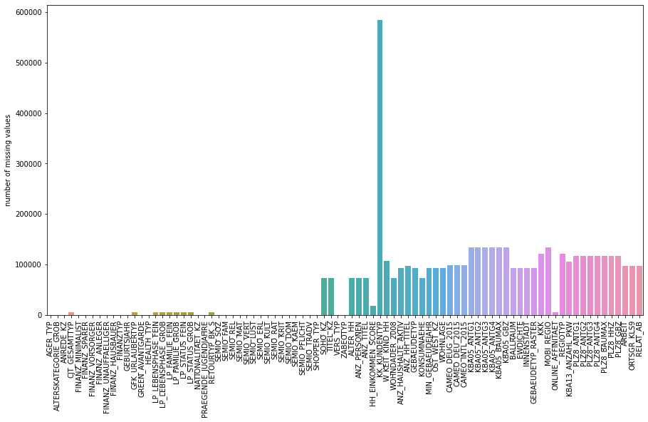

```python
fig, ax = plt.subplots(1,1, figsize=(15,8))
sns.barplot(azdias.columns, number_nan, ax=ax)
ax.set_xticklabels(azdias.columns,rotation=90)
ax.set_ylabel("number of missing values")
plt.show()
```

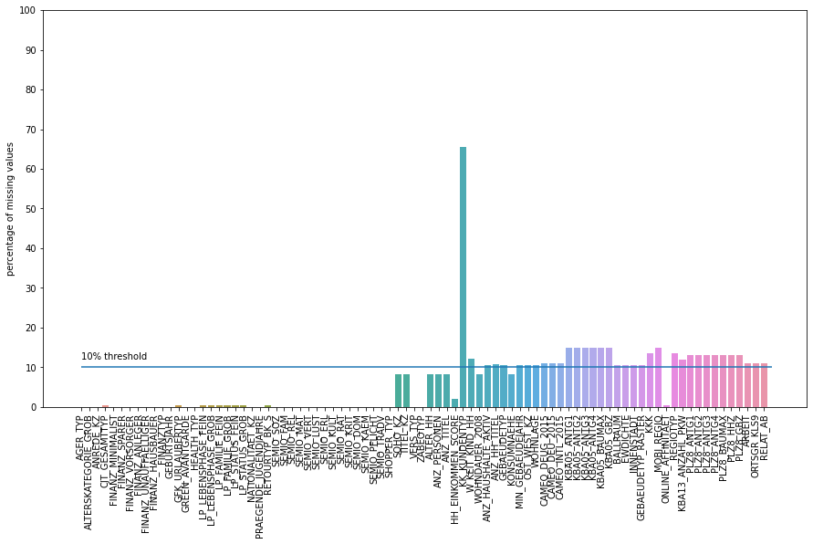

```python
fig, ax = plt.subplots(1,1, figsize=(15,8))
sns.barplot(azdias.columns, (number_nan/len(azdias))*100, ax=ax)
ax.set_xticklabels(azdias.columns,rotation=90)
ax.set_ylabel("percentage of missing values")
ax.set_yticks([n for n in range(0,110,10)])
ax.hlines(10, 0, 85)
ax.text(0, 12, "10% threshold")
plt.ylim(0,100)
plt.show()
```

Approximatly half of the features/columns already contain approximatly 10-15% (horizontal line in figure above) missing values. The column KK_KUNDENTYP exihibts an exceptionally high number of missing values (almost 70%). At this point, it is already advisible to exclude this feature/column from further analysis.

```python
azdias_copy = azdias.copy()
```

```python
# Identify missing or unknown data values and convert them to NaNs.
for col in columns_dataset:
    nan_encoded = feat_info[feat_info["attribute"]==col]["missing_or_unknown"].iloc[0]
    nan_decoded = nan_encoded.split("[")[1].split("]")[0].split(",")
    azdias_copy[col] = np.where(azdias_copy[col].isin(nan_decoded), np.nan, azdias_copy[col])
```

```python
azdias_copy.head()
```

|  | AGER_TYP | ALTERSKATEGORIE_GROB | ANREDE_KZ | CJT_GESAMTTYP | FINANZ_MINIMALIST | FINANZ_SPARER | FINANZ_VORSORGER | FINANZ_ANLEGER | FINANZ_UNAUFFAELLIGER | FINANZ_HAUSBAUER | ... | PLZ8_ANTG1 | PLZ8_ANTG2 | PLZ8_ANTG3 | PLZ8_ANTG4 | PLZ8_BAUMAX | PLZ8_HHZ | PLZ8_GBZ | ARBEIT | ORTSGR_KLS9 | RELAT_AB |
| --- | --- | --- | --- | --- | --- | --- | --- | --- | --- | --- | --- | --- | --- | --- | --- | --- | --- | --- | --- | --- | --- |
| 0 | NaN | 2.0 | 1.0 | 2.0 | 3.0 | 4.0 | 3.0 | 5.0 | 5.0 | 3.0 | ... | NaN | NaN | NaN | NaN | NaN | NaN | NaN | NaN | NaN | NaN |
| 1 | NaN | 1.0 | 2.0 | 5.0 | 1.0 | 5.0 | 2.0 | 5.0 | 4.0 | 5.0 | ... | 2.0 | 3.0 | 2.0 | 1.0 | 1.0 | 5.0 | 4.0 | 3.0 | 5.0 | 4.0 |
| 2 | NaN | 3.0 | 2.0 | 3.0 | 1.0 | 4.0 | 1.0 | 2.0 | 3.0 | 5.0 | ... | 3.0 | 3.0 | 1.0 | 0.0 | 1.0 | 4.0 | 4.0 | 3.0 | 5.0 | 2.0 |
| 3 | 2.0 | 4.0 | 2.0 | 2.0 | 4.0 | 2.0 | 5.0 | 2.0 | 1.0 | 2.0 | ... | 2.0 | 2.0 | 2.0 | 0.0 | 1.0 | 3.0 | 4.0 | 2.0 | 3.0 | 3.0 |
| 4 | NaN | 3.0 | 1.0 | 5.0 | 4.0 | 3.0 | 4.0 | 1.0 | 3.0 | 2.0 | ... | 2.0 | 4.0 | 2.0 | 1.0 | 2.0 | 3.0 | 3.0 | 4.0 | 6.0 | 5.0 |

5 rows × 85 columns

A brief glimpse at the AGER_TYP column suggest that decoding of missing/unknown values to np.nan has been successfull. However, let's do a sanity check and compare the number of values encoded as 9 in column ALTERSKATEGORIE_GROB (one of the missing-/unknown value codes) before and after transformation. We expect that all values encoding the number 9 have been converted into np.nan.

```python
indices_nan = azdias.loc[azdias["ALTERSKATEGORIE_GROB"]==9, ["ALTERSKATEGORIE_GROB"]].index.values
print(f"number of nan values encoded as 9: {len(indices_nan)}")
```

```
number of nan values encoded as 9: 2881
```

```python
pd.isna(azdias_copy.loc[indices_nan]["ALTERSKATEGORIE_GROB"]).sum()
```

```
2881
```

All number 9 values have been converted to np.nan, which confirms that the conversion into nan has been successfull.

#### Step 1.1.2: Assess Missing Data in Each Column

How much missing data is present in each column? There are a few columns that are outliers in terms of the proportion of values that are missing. You will want to use matplotlib's [`hist()`](https://matplotlib.org/api/_as_gen/matplotlib.pyplot.hist.html) function to visualize the distribution of missing value counts to find these columns. Identify and document these columns. While some of these columns might have justifications for keeping or re-encoding the data, for this project you should just remove them from the dataframe. (Feel free to make remarks about these outlier columns in the discussion, however!)

For the remaining features, are there any patterns in which columns have, or share, missing data?

```python
# Perform an assessment of how much missing data there is in each column of the
# dataset.
number_nan_pp = azdias_copy.apply(lambda col: pd.isna(col).sum(), 0).values
```

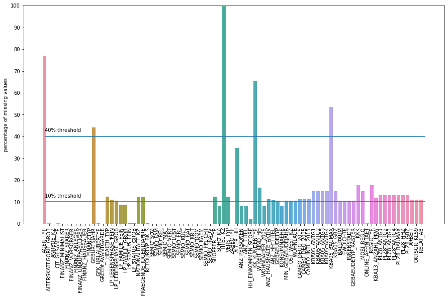

```python
fig, ax = plt.subplots(1,1, figsize=(15,8))
sns.barplot(azdias_copy.columns, (number_nan_pp/len(azdias_copy))*100, ax=ax)
ax.set_xticklabels(azdias.columns,rotation=90)
ax.set_ylabel("percentage of missing values")
ax.set_yticks([n for n in range(0,110,10)])
ax.hlines(10, 0, 85)
ax.text(0, 12, "10% threshold")
ax.hlines(40, 0, 85)
ax.text(0, 42, "40% threshold")
plt.ylim(0,100)
plt.show()
```

```python
# Investigate patterns in the amount of missing data in each column.
missing_values = pd.DataFrame({"feature":azdias_copy.columns.values, "number_nan":number_nan_pp,"percentage_missing":(number_nan_pp/len(azdias_copy))*100})
missing_values_keep = missing_values[missing_values["percentage_missing"] < 30]
missing_values_keep
```

|  | feature | number_nan | percentage_missing |
| --- | --- | --- | --- |
| 1 | ALTERSKATEGORIE_GROB | 2881 | 0.323264 |
| 2 | ANREDE_KZ | 0 | 0.000000 |
| 3 | CJT_GESAMTTYP | 4854 | 0.544646 |
| 4 | FINANZ_MINIMALIST | 0 | 0.000000 |
| 5 | FINANZ_SPARER | 0 | 0.000000 |
| ... | ... | ... | ... |
| 80 | PLZ8_HHZ | 116515 | 13.073637 |
| 81 | PLZ8_GBZ | 116515 | 13.073637 |
| 82 | ARBEIT | 97375 | 10.926022 |
| 83 | ORTSGR_KLS9 | 97274 | 10.914689 |
| 84 | RELAT_AB | 97375 | 10.926022 |

79 rows × 3 columns

```python
len(missing_values_keep)
```

```
79
```

Let's see if features share similar number of missing values across different features. Let's define a threshold of 5%, i.e. for any feature subset (reference feature) including only missing values, other features are considered as similar (in terms of missing values for same samples) if the corresponding number of missing values is <= 5% compared with the number of missing values in the reference feature. For that comparison, I will exclude features with >30% missing values (see figure above).

```python
for col in missing_values_keep[missing_values["percentage_missing"] > 0]["feature"]:
    nan_subset = azdias_copy.loc[pd.isna(azdias_copy[col])]
    nan_subset.drop(columns=[col, "TITEL_KZ", "AGER_TYP", "KK_KUNDENTYP",
                             "GEBURTSJAHR", "KBA05_BAUMAX", "ALTER_HH"],inplace=True)
    other_nan = nan_subset.apply(lambda col: pd.isna(col).sum(), 0)
    other_nan_filtered = other_nan[(other_nan/len(nan_subset))>0.95]
    print(f"reference column {col}; number of nan {len(nan_subset)}")
    print(other_nan_filtered)
    print(f"number of features with similar nan count: {len(other_nan_filtered)}")
    print("-------------")
```

```
reference column ALTERSKATEGORIE_GROB; number of nan 2881
HEALTH_TYP     2881
SHOPPER_TYP    2881
VERS_TYP       2881
dtype: int64
number of features with similar nan count: 3
-------------
reference column CJT_GESAMTTYP; number of nan 4854
GFK_URLAUBERTYP        4854
LP_LEBENSPHASE_FEIN    4854
LP_LEBENSPHASE_GROB    4854
LP_FAMILIE_FEIN        4854
LP_FAMILIE_GROB        4854
LP_STATUS_FEIN         4854
LP_STATUS_GROB         4854
RETOURTYP_BK_S         4854
ONLINE_AFFINITAET      4854
dtype: int64
number of features with similar nan count: 9
-------------
reference column GFK_URLAUBERTYP; number of nan 4854
CJT_GESAMTTYP          4854
LP_LEBENSPHASE_FEIN    4854
LP_LEBENSPHASE_GROB    4854
LP_FAMILIE_FEIN        4854
LP_FAMILIE_GROB        4854
LP_STATUS_FEIN         4854
LP_STATUS_GROB         4854
RETOURTYP_BK_S         4854
ONLINE_AFFINITAET      4854
dtype: int64
number of features with similar nan count: 9
-------------
reference column HEALTH_TYP; number of nan 111196
NATIONALITAET_KZ    108315
SHOPPER_TYP         111196
VERS_TYP            111196
dtype: int64
number of features with similar nan count: 3
-------------
```

[output cut: 998 more lines]

```
MOBI_REGIO             93303
REGIOTYP               93470
KBA13_ANZAHL_PKW       93192
PLZ8_ANTG1             93225
PLZ8_ANTG2             93225
PLZ8_ANTG3             93225
PLZ8_ANTG4             93225
PLZ8_BAUMAX            93225
PLZ8_HHZ               93225
PLZ8_GBZ               93225
ARBEIT                 97375
ORTSGR_KLS9            97274
dtype: int64
number of features with similar nan count: 31
-------------
```

Let's try to figure out if columns that share similar numbers of missing values, actually share missing values across same samples, i.e. missing values across multiple columns belong to same samples (rows).

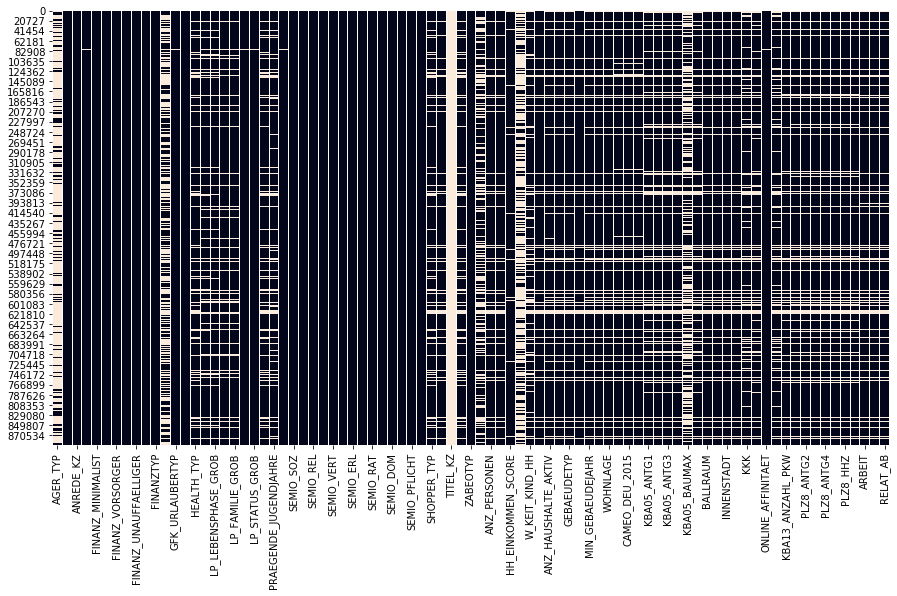

```python
fig, ax = plt.subplots(1,1,figsize=(15,8))
sns.heatmap(azdias_copy.isnull(), cbar=False, ax=ax)
```

As can be seen from the figure above, there is a high correlation in rows for missing values across multiple columns.

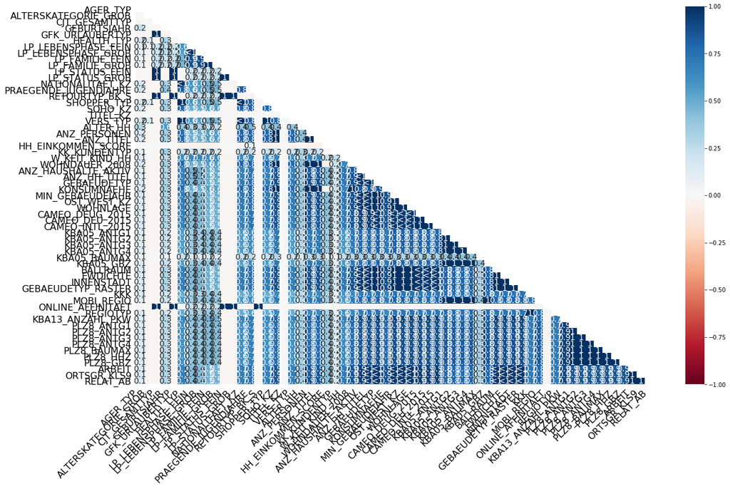

```python
missingno.heatmap(azdias_copy)
```

Accordingly, this is also reflected in high correlation values between missing values in different columns, i.e. missing values in same rows samples across different columns.

```python
# Remove the outlier columns from the dataset. (You'll perform other data
# engineering tasks such as re-encoding and imputation later.)

azdias_copy = azdias_copy.drop(columns=["TITEL_KZ", "AGER_TYP", "KK_KUNDENTYP",
                             "GEBURTSJAHR", "KBA05_BAUMAX", "ALTER_HH"])
```

#### Discussion 1.1.2: Assess Missing Data in Each Column

The amount of missing data varies from 0-100% after decoding missing values for each column/featute. I decided to remove features/columns that have more than 30% missing values.

```python
np.percentile(missing_values_keep["percentage_missing"],99)
```

```
17.73566825736826
```

Looking at the 2 heatmap figures above, which display missing value rows as white lines and correlation metrics, respectively, we clearly see a trend that different columns (sets with similar number of missing values in columns) have missing values in same rows/samples.

#### Step 1.1.3: Assess Missing Data in Each Row

Now, you'll perform a similar assessment for the rows of the dataset. How much data is missing in each row? As with the columns, you should see some groups of points that have a very different numbers of missing values. Divide the data into two subsets: one for data points that are above some threshold for missing values, and a second subset for points below that threshold.

In order to know what to do with the outlier rows, we should see if the distribution of data values on columns that are not missing data (or are missing very little data) are similar or different between the two groups. Select at least five of these columns and compare the distribution of values.

- You can use seaborn's [`countplot()`](https://seaborn.pydata.org/generated/seaborn.countplot.html) function to create a bar chart of code frequencies and matplotlib's [`subplot()`](https://matplotlib.org/api/_as_gen/matplotlib.pyplot.subplot.html) function to put bar charts for the two subplots side by side.
- To reduce repeated code, you might want to write a function that can perform this comparison, taking as one of its arguments a column to be compared.

Depending on what you observe in your comparison, this will have implications on how you approach your conclusions later in the analysis. If the distributions of non-missing features look similar between the data with many missing values and the data with few or no missing values, then we could argue that simply dropping those points from the analysis won't present a major issue. On the other hand, if the data with many missing values looks very different from the data with few or no missing values, then we should make a note on those data as special. We'll revisit these data later on. **Either way, you should continue your analysis for now using just the subset of the data with few or no missing values.**

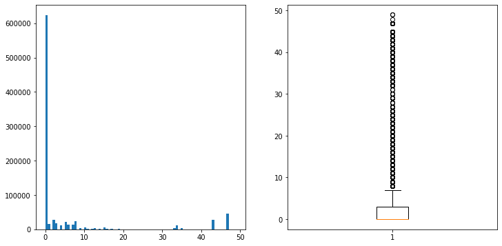

```python
# How much data is missing in each row of the dataset?
nan_row = azdias_copy.isna().sum(axis=1)

fig, ax = plt.subplots(1,2, figsize=(12,6))
ax[0].hist(nan_row, bins=len(azdias_copy.columns))
ax[1].boxplot(nan_row)
plt.show()
```

```python
print(f"max percentage of missing values by row: {np.round(np.max(nan_row)/len(azdias_copy.columns),2)}")
```

```
max percentage of missing values by row: 0.62
```

```python
# Write code to divide the data into two subsets based on the number of missing
# values in each row.
azdias_nan_row_below = azdias_copy[nan_row<=16].copy()
azdias_nan_row_above = azdias_copy[nan_row>16]
```

```python
# Compare the distribution of values for at least five columns where there are
# no or few missing values, between the two subsets.
no_nan_columns = random.sample(missing_values_keep[(missing_values_keep["percentage_missing"] == 0)]["feature"].values.tolist(), 5)
low_nan_columns = random.sample(missing_values_keep[(missing_values_keep["percentage_missing"] > 0) &\
                                               (missing_values_keep["percentage_missing"] < 5)]["feature"].values.tolist(), 5)
high_nan_columns = random.sample(missing_values_keep[missing_values_keep["percentage_missing"] > 12]["feature"].values.tolist(), 5)
```

```python
def compare_distribution(columns, dataset_1, dataset_2):
    fig, ax = plt.subplots(5, 2, figsize=(15,10))
    for idx, col in enumerate(columns):
        sns.countplot(x=col, data=dataset_1, ax=ax[idx][0])
        sns.countplot(x=col, data=dataset_2, ax=ax[idx][1])
    ax[0,0].set_title("Dataset nan by row below thresh", size=16)
    ax[0,1].set_title("Dataset nan by row above thresh", size=16)
    plt.tight_layout()
```

Comparison of distribution of values for columns/features without missing values

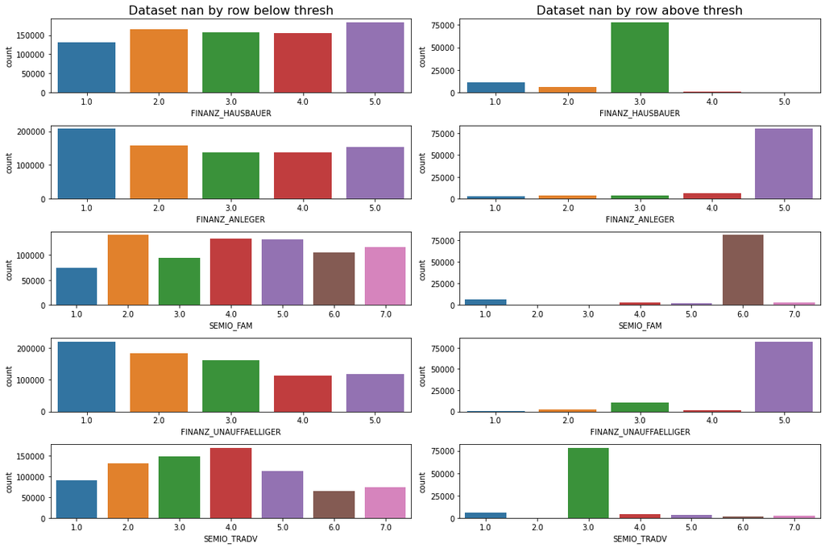

```python
compare_distribution(no_nan_columns, azdias_nan_row_below, azdias_nan_row_above)
```

Comparison of distribution of values for columns/features with low percentage (below 5%) of missing values

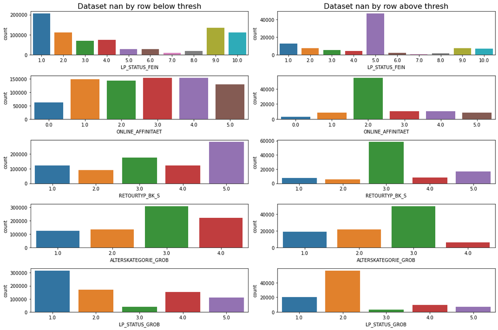

```python
compare_distribution(low_nan_columns, azdias_nan_row_below, azdias_nan_row_above)
```

Comparison of distribution of values for columns/features with high percentage (above 12%) of missing values

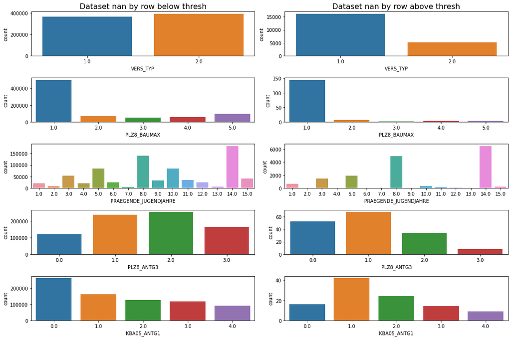

```python
compare_distribution(high_nan_columns, azdias_nan_row_below, azdias_nan_row_above)
```

#### Discussion 1.1.3: Assess Missing Data in Each Row

This is in accordance with our previous finding, which showed a strong correlation between missing values and rows/samples across multiple columns. As such, we can expect that removing rows in columns with high number of missing values will much less impact the distribution of values.

Overall, the results indicate that missing values are not missing completely at random.

```python
1-len(azdias_nan_row_below)/len(azdias_copy)
```

```
0.10819875204915508
```

Continuing with the subset below the specified row NaN threshold, reduces the total sample size by approx. 10.8%

### Step 1.2: Select and Re-Encode Features

Checking for missing data isn't the only way in which you can prepare a dataset for analysis. Since the unsupervised learning techniques to be used will only work on data that is encoded numerically, you need to make a few encoding changes or additional assumptions to be able to make progress. In addition, while almost all of the values in the dataset are encoded using numbers, not all of them represent numeric values. Check the third column of the feature summary (`feat_info`) for a summary of types of measurement.

- For numeric and interval data, these features can be kept without changes.
- Most of the variables in the dataset are ordinal in nature. While ordinal values may technically be non-linear in spacing, make the simplifying assumption that the ordinal variables can be treated as being interval in nature (that is, kept without any changes).
- Special handling may be necessary for the remaining two variable types: categorical, and 'mixed'.

In the first two parts of this sub-step, you will perform an investigation of the categorical and mixed-type features and make a decision on each of them, whether you will keep, drop, or re-encode each. Then, in the last part, you will create a new data frame with only the selected and engineered columns.

Data wrangling is often the trickiest part of the data analysis process, and there's a lot of it to be done here. But stick with it: once you're done with this step, you'll be ready to get to the machine learning parts of the project!

```python
# How many features are there of each data type?
feat_info.groupby("type").count()
```

| type | attribute | information_level | missing_or_unknown |
| --- | --- | --- | --- |
| categorical | 21 | 21 | 21 |
| interval | 1 | 1 | 1 |
| mixed | 7 | 7 | 7 |
| numeric | 7 | 7 | 7 |
| ordinal | 49 | 49 | 49 |

Overall, the dataset contains 21 feature s of categorical type, 49 of ordinal type, 1 feature of interval type and each 7 of type mixed and numeric.

#### Step 1.2.1: Re-Encode Categorical Features

For categorical data, you would ordinarily need to encode the levels as dummy variables. Depending on the number of categories, perform one of the following:

- For binary (two-level) categoricals that take numeric values, you can keep them without needing to do anything.
- There is one binary variable that takes on non-numeric values. For this one, you need to re-encode the values as numbers or create a dummy variable.
- For multi-level categoricals (three or more values), you can choose to encode the values using multiple dummy variables (e.g. via [OneHotEncoder](http://scikit-learn.org/stable/modules/generated/sklearn.preprocessing.OneHotEncoder.html)), or (to keep things straightforward) just drop them from the analysis. As always, document your choices in the Discussion section.

```python
# Assess categorical variables: which are binary, which are multi-level, and
# which one needs to be re-encoded?
columns_categorical = feat_info.loc[feat_info["type"]=="categorical", "attribute"]
```

```python
for col in columns_categorical:
    try:
        values = azdias_nan_row_below[col].dropna().values
    except KeyError:
        print(f"column {col} removed")
        continue

    print(f"{col} number of variables: {len(set(values))}")

    if len(set(values)) == 2:
        val_types = [(type(v) == int or type(v) == float) for v in set(values)]
        if not all(val_types):
            print(f"not numeric values for column {col} {set(values)}")
```

```
column AGER_TYP removed
ANREDE_KZ number of variables: 2
not numeric values for column ANREDE_KZ {1.0, 2.0}
CJT_GESAMTTYP number of variables: 6
FINANZTYP number of variables: 6
GFK_URLAUBERTYP number of variables: 12
GREEN_AVANTGARDE number of variables: 2
not numeric values for column GREEN_AVANTGARDE {0.0, 1.0}
LP_FAMILIE_FEIN number of variables: 11
LP_FAMILIE_GROB number of variables: 5
LP_STATUS_FEIN number of variables: 10
LP_STATUS_GROB number of variables: 5
NATIONALITAET_KZ number of variables: 3
SHOPPER_TYP number of variables: 4
SOHO_KZ number of variables: 2
not numeric values for column SOHO_KZ {0.0, 1.0}
column TITEL_KZ removed
VERS_TYP number of variables: 2
not numeric values for column VERS_TYP {1.0, 2.0}
ZABEOTYP number of variables: 6
column KK_KUNDENTYP removed
GEBAEUDETYP number of variables: 7
OST_WEST_KZ number of variables: 2
not numeric values for column OST_WEST_KZ {'W', 'O'}
CAMEO_DEUG_2015 number of variables: 9
CAMEO_DEU_2015 number of variables: 44
```

Let's check why the numeric values for columns ANREDE_KZ, GREEN_AVANTGARDE, SOHO_KZ and VERS_TYP have not been identified as either int or float types.

```python
for col in ["ANREDE_KZ", "GREEN_AVANTGARDE", "SOHO_KZ", "VERS_TYP"]:
     print(f"value types for column {col}: {[type(v)for v in set(azdias_nan_row_below[col].dropna().values)]}")
```

```
value types for column ANREDE_KZ: [<class 'numpy.float64'>, <class 'numpy.float64'>]
value types for column GREEN_AVANTGARDE: [<class 'numpy.float64'>, <class 'numpy.float64'>]
value types for column SOHO_KZ: [<class 'numpy.float64'>, <class 'numpy.float64'>]
value types for column VERS_TYP: [<class 'numpy.float64'>, <class 'numpy.float64'>]
```

As we can see, the values are encoded as numpy.float64 instead of python float type. Overall, ANREDE_KZ, GREEN_AVANTGARDE, SOHO_KZ, VERS_TYP and OST_WEST_KZ encode for binary type categorical variables, whereas OST_WEST_KZ is str type and needs to be re-encoded as numeric dummy variables. All the other features display above are multi-level variable type that would also require re-encoding into dummy variables.

```python
columns_drop = ["CAMEO_DEUG_2015", "LP_STATUS_FEIN", "LP_FAMILIE_FEIN", "GFK_URLAUBERTYP", "CAMEO_DEU_2015"]
azdias_nan_row_below.drop(columns=columns_drop, inplace=True)
```

Exclude categorical columns that have already been dropped (too many levels vs. high row NaN percentage; see sections above) from encoding into dummy variables.

```python
# Re-encode categorical variable(s) to be kept in the analysis.
columns_reencode = set(columns_categorical).difference(set(columns_drop)).difference(set(['AGER_TYP', 'KK_KUNDENTYP', 'TITEL_KZ']))
azdias_recoded = pd.get_dummies(azdias_nan_row_below, columns=columns_reencode)
```

```python
azdias_recoded.head()
```

|  | ALTERSKATEGORIE_GROB | FINANZ_MINIMALIST | FINANZ_SPARER | FINANZ_VORSORGER | FINANZ_ANLEGER | FINANZ_UNAUFFAELLIGER | FINANZ_HAUSBAUER | HEALTH_TYP | LP_LEBENSPHASE_FEIN | LP_LEBENSPHASE_GROB | ... | ANREDE_KZ_1.0 | ANREDE_KZ_2.0 | CJT_GESAMTTYP_1.0 | CJT_GESAMTTYP_2.0 | CJT_GESAMTTYP_3.0 | CJT_GESAMTTYP_4.0 | CJT_GESAMTTYP_5.0 | CJT_GESAMTTYP_6.0 | VERS_TYP_1.0 | VERS_TYP_2.0 |
| --- | --- | --- | --- | --- | --- | --- | --- | --- | --- | --- | --- | --- | --- | --- | --- | --- | --- | --- | --- | --- | --- |
| 1 | 1.0 | 1.0 | 5.0 | 2.0 | 5.0 | 4.0 | 5.0 | 3.0 | 21.0 | 6.0 | ... | 0 | 1 | 0 | 0 | 0 | 0 | 1 | 0 | 0 | 1 |
| 2 | 3.0 | 1.0 | 4.0 | 1.0 | 2.0 | 3.0 | 5.0 | 3.0 | 3.0 | 1.0 | ... | 0 | 1 | 0 | 0 | 1 | 0 | 0 | 0 | 1 | 0 |
| 3 | 4.0 | 4.0 | 2.0 | 5.0 | 2.0 | 1.0 | 2.0 | 2.0 | NaN | NaN | ... | 0 | 1 | 0 | 1 | 0 | 0 | 0 | 0 | 1 | 0 |
| 4 | 3.0 | 4.0 | 3.0 | 4.0 | 1.0 | 3.0 | 2.0 | 3.0 | 32.0 | 10.0 | ... | 1 | 0 | 0 | 0 | 0 | 0 | 1 | 0 | 0 | 1 |
| 5 | 1.0 | 3.0 | 1.0 | 5.0 | 2.0 | 2.0 | 5.0 | 3.0 | 8.0 | 2.0 | ... | 0 | 1 | 0 | 1 | 0 | 0 | 0 | 0 | 0 | 1 |

5 rows × 113 columns

```python
len(azdias_recoded)
```

```
794792
```

#### Discussion 1.2.1: Re-Encode Categorical Features

In terms of engineering, the feature OST_WEST_KZ was transformed to encode numeric values (str in the original dataset). No further engineering was required, as the corresponding unique values are binary. All remaining categorical values have been transformed using one-hot encoding (for each value a new column is generated, encoding either a 1 if the corresponding value is present, or alternatively 0, if not present). Of note, all missing values have been dropped during the process of dummy encoding!

#### Step 1.2.2: Engineer Mixed-Type Features

There are a handful of features that are marked as "mixed" in the feature summary that require special treatment in order to be included in the analysis. There are two in particular that deserve attention; the handling of the rest are up to your own choices:

- "PRAEGENDE_JUGENDJAHRE" combines information on three dimensions: generation by decade, movement (mainstream vs. avantgarde), and nation (east vs. west). While there aren't enough levels to disentangle east from west, you should create two new variables to capture the other two dimensions: an interval-type variable for decade, and a binary variable for movement.
- "CAMEO_INTL_2015" combines information on two axes: wealth and life stage. Break up the two-digit codes by their 'tens'-place and 'ones'-place digits into two new ordinal variables (which, for the purposes of this project, is equivalent to just treating them as their raw numeric values).
- If you decide to keep or engineer new features around the other mixed-type features, make sure you note your steps in the Discussion section.

Be sure to check `Data_Dictionary.md` for the details needed to finish these tasks.

Levels/Variables encoding in PRAEGENDE_JUGENDJAHRE:

- 1: 40s - war years (Mainstream, E+W)
- 2: 40s - reconstruction years (Avantgarde, E+W)
- 3: 50s - economic miracle (Mainstream, E+W)
- 4: 50s - milk bar / Individualisation (Avantgarde, E+W)
- 5: 60s - economic miracle (Mainstream, E+W)
- 6: 60s - generation 68 / student protestors (Avantgarde, W)
- 7: 60s - opponents to the building of the Wall (Avantgarde, E)
- 8: 70s - family orientation (Mainstream, E+W)
- 9: 70s - peace movement (Avantgarde, E+W)
- 10: 80s - Generation Golf (Mainstream, W)
- 11: 80s - ecological awareness (Avantgarde, W)
- 12: 80s - FDJ / communist party youth organisation (Mainstream, E)
- 13: 80s - Swords into ploughshares (Avantgarde, E)
- 14: 90s - digital media kids (Mainstream, E+W)
- 15: 90s - ecological awareness (Avantgarde, E+W)

Levels/Variables encoding in CAMEO_INTL_2015 feature:

- 11: Wealthy Households - Pre-Family Couples & Singles
- 12: Wealthy Households - Young Couples With Children
- 13: Wealthy Households - Families With School Age Children
- 14: Wealthy Households - Older Families & Mature Couples
- 15: Wealthy Households - Elders In Retirement
- 21: Prosperous Households - Pre-Family Couples & Singles
- 22: Prosperous Households - Young Couples With Children
- 23: Prosperous Households - Families With School Age Children
- 24: Prosperous Households - Older Families & Mature Couples
- 25: Prosperous Households - Elders In Retirement
- 31: Comfortable Households - Pre-Family Couples & Singles
- 32: Comfortable Households - Young Couples With Children
- 33: Comfortable Households - Families With School Age Children
- 34: Comfortable Households - Older Families & Mature Couples
- 35: Comfortable Households - Elders In Retirement
- 41: Less Affluent Households - Pre-Family Couples & Singles
- 42: Less Affluent Households - Young Couples With Children
- 43: Less Affluent Households - Families With School Age Children
- 44: Less Affluent Households - Older Families & Mature Couples
- 45: Less Affluent Households - Elders In Retirement
- 51: Poorer Households - Pre-Family Couples & Singles
- 52: Poorer Households - Young Couples With Children
- 53: Poorer Households - Families With School Age Children
- 54: Poorer Households - Older Families & Mature Couples
- 55: Poorer Households - Elders In Retirement

```python
len(azdias_recoded.columns)
```

```
113
```

```python
azdias_feat_eng = azdias_recoded.copy()
```

```python
# Investigate "CAMEO_INTL_2015" and engineer two new variables.
orig_val = []
dec_set = [[v]*5 for v in range(10,60,10) ]
for dec_val_set in dec_set:
    add_v = 1
    for dec_val in dec_val_set:
        orig_val.append(dec_val+add_v)
        add_v+=1
cameo_wealth_mapping = {v:np.array(dec_set).flatten()[idx] for idx,v in enumerate(orig_val)}
cameo_ls_mapping = {v:v%np.array(dec_set).flatten()[idx] for idx,v in enumerate(orig_val)}
```

```python
cameo_wealth_mapping
```

```
{11: 10,
 12: 10,
 13: 10,
 14: 10,
 15: 10,
 21: 20,
 22: 20,
 23: 20,
 24: 20,
 25: 20,
 31: 30,
 32: 30,
 33: 30,
 34: 30,
 35: 30,
 41: 40,
 42: 40,
 43: 40,
 44: 40,
 45: 40,
 51: 50,
 52: 50,
 53: 50,
 54: 50,
 55: 50}
```

```python
cameo_ls_mapping
```

```
{11: 1,
 12: 2,
 13: 3,
 14: 4,
 15: 5,
 21: 1,
 22: 2,
 23: 3,
 24: 4,
 25: 5,
 31: 1,
 32: 2,
 33: 3,
 34: 4,
 35: 5,
 41: 1,
 42: 2,
 43: 3,
 44: 4,
 45: 5,
 51: 1,
 52: 2,
 53: 3,
 54: 4,
 55: 5}
```

As can be seen above, the corresponding mapping dictionaries are correct. There is no consistent pattern how values are encoded for PRAEGENDE_JUGENDJAHRE (from Data_Dictionary.md). As such, we are going to construct the cognate mapping dictionaries manually.

```python
# Investigate "PRAEGENDE_JUGENDJAHRE" and engineer two new variables.
prae_jgd_decade_mapping = {1:40, 2:40, 3:50, 4:50, 5:60, 6:60, 7:60,
                           8:70, 9:70, 10:80, 11:80, 12:80, 13:80, 14:90, 15:90}
prae_jgd_movement_mapping = {1:0, 2:1, 3:0, 4:1, 5:0, 6:1, 7:1, 8:0,
                             9:1, 10:0, 11:1, 12:0, 13:1, 14:0, 15:1}
```

```python
azdias_feat_eng["PRAEGENDE_JUGENDJAHRE_DECADE"] = azdias_feat_eng["PRAEGENDE_JUGENDJAHRE"].dropna().apply(lambda col: prae_jgd_decade_mapping[float(col)])
azdias_feat_eng["PRAEGENDE_JUGENDJAHRE_MOV"] = azdias_feat_eng["PRAEGENDE_JUGENDJAHRE"].dropna().apply(lambda col: prae_jgd_movement_mapping[float(col)])
```

```python
azdias_feat_eng["CAMEO_INTL_2015_WEALTH"] = azdias_feat_eng["CAMEO_INTL_2015"].dropna().apply(lambda col: cameo_wealth_mapping[float(col)])
azdias_feat_eng["CAMEO_INTL_2015_LIFE"] = azdias_feat_eng["CAMEO_INTL_2015"].dropna().apply(lambda col: cameo_ls_mapping[float(col)])
```

Let's do a quick sanity check and find out if the newly engineered features are encoded as expected.

```python
azdias_nan_row_below["PRAEGENDE_JUGENDJAHRE"].head()
```

```
1    14.0
2    15.0
3     8.0
4     8.0
5     3.0
Name: PRAEGENDE_JUGENDJAHRE, dtype: float64
```

```python
azdias_feat_eng["PRAEGENDE_JUGENDJAHRE_DECADE"].head()
```

```
1    90.0
2    90.0
3    70.0
4    70.0
5    50.0
Name: PRAEGENDE_JUGENDJAHRE_DECADE, dtype: float64
```

```python
azdias_feat_eng["PRAEGENDE_JUGENDJAHRE_MOV"].head()
```

```
1    0.0
2    1.0
3    0.0
4    0.0
5    0.0
Name: PRAEGENDE_JUGENDJAHRE_MOV, dtype: float64
```

```python
azdias_nan_row_below["CAMEO_INTL_2015"].head()
```

```
1    51
2    24
3    12
4    43
5    54
Name: CAMEO_INTL_2015, dtype: object
```

```python
azdias_feat_eng["CAMEO_INTL_2015_WEALTH"].head()
```

```
1    50.0
2    20.0
3    10.0
4    40.0
5    50.0
Name: CAMEO_INTL_2015_WEALTH, dtype: float64
```

```python
azdias_feat_eng["CAMEO_INTL_2015_LIFE"].head()
```

```
1    1.0
2    4.0
3    2.0
4    3.0
5    4.0
Name: CAMEO_INTL_2015_LIFE, dtype: float64
```

Both original features have been transformed into 2 new features each as expected (see expected mapping of original values)

Let's have a look what other mixed features are present in the current dataset

```python
columns_mixed = feat_info.loc[feat_info["type"]=="mixed", "attribute"]
for col in columns_mixed:
    print(col, col in azdias_recoded.columns)
```

```
LP_LEBENSPHASE_FEIN True
LP_LEBENSPHASE_GROB True
PRAEGENDE_JUGENDJAHRE True
WOHNLAGE True
CAMEO_INTL_2015 True
KBA05_BAUMAX False
PLZ8_BAUMAX True
```

LP_LEBENSPHASE_FEIN and LP_LEBENSPHASE_GROB describe both the life stage at different levels of granularity, which encodes multi-level information about age, income and family status. However, if we look at other features like LP_FAMILIE_FEIN, LP_FAMILIE_GROB, LP_STATUS_FEIN and LP_STATUS_GROB, we can see that the same information encoded in LP_LEBENSPHASE_FEIN and LP_LEBENSPHASE_GROB is basically encoded in these features. As such, I decided to drop LP_LEBENSPHASE_FEIN and LP_LEBENSPHASE_GROB due to redundant information.

The feature WOHNLAGE encodes information at two levels, i.e. urban vs. rural residential area and the quality of the neighborhood. I decided to split the feature into a new ordinal-type feature encoding quality of the neighborhood. Sinco no information on neighborhood quality is availabe for rural areas, observations with rural residential area will be mapped to the variable representing "no score calculated". All other values remain unchanged. The second feature will be binary-type and simply encoding if an observation represents rural or urban residential area.

Neighborhood quality (or rural flag)

- -1: unknown
- 0: no score calculated
- 1: very good neighborhood
- 2: good neighborhood
- 3: average neighborhood
- 4: poor neighborhood
- 5: very poor neighborhood
- 7: rural neighborhood
- 8: new building in rural neighborhood

Similarly, PLZ8_BAUMAX encodes information at two levels, i.e. residential building type vs. business building type and the number of housing units. I decided not to conduct any reengineering, since we can't fully resolve the levels in new features (no representation of housing units for business building type).

Most common building type within the PLZ8 region

- -1: unknown
- 0: unknown
- 1: mainly 1-2 family homes
- 2: mainly 3-5 family homes
- 3: mainly 6-10 family homes
- 4: mainly 10+ family homes
- 5: mainly business buildings

```python
residential_area_type_mapping = {0:1, 1:1, 2:1, 3:1, 4:1, 5:1, 7:0, 8:0}
residential_area_quality_mapping = {7:0, 8:0}
```

```python
azdias_feat_eng["WOHNLAGE_TYPE"] = azdias_feat_eng["WOHNLAGE"].dropna().apply(lambda col: residential_area_type_mapping[float(col)])
azdias_feat_eng["WOHNLAGE_QUALITY"] = azdias_feat_eng["WOHNLAGE"].dropna().apply(lambda col: residential_area_quality_mapping[float(col)]\
                                           if col in [7,8] else col)
```

```python
azdias_feat_eng["WOHNLAGE_TYPE"].head()
```

```
1    1
2    1
3    0
4    1
5    0
Name: WOHNLAGE_TYPE, dtype: int64
```

```python
azdias_feat_eng["WOHNLAGE_QUALITY"].head()
```

```
1    4.0
2    2.0
3    0.0
4    3.0
5    0.0
Name: WOHNLAGE_QUALITY, dtype: float64
```

```python
azdias_feat_eng["WOHNLAGE"].head()
```

```
1    4.0
2    2.0
3    7.0
4    3.0
5    7.0
Name: WOHNLAGE, dtype: float64
```

The original feature has been transformed into 2 new features each as expected (see expected mapping of original values)

#### Discussion 1.2.2: Engineer Mixed-Type Features

PRAEGENDE_JUGENDJAHRE and CAMEO_INTL_2015 have been reengineered such that each two new features were created describing the two levels encoded within the original data. For PRAEGENDE_JUGENDJAHRE a new feature with ordinal variables was created, which encodes the generation decade information present in the original multilevel feature. A second binary feature was created that directly indicates if one of the two lifestyle movement values from the original data is true for the cognate observation.  
Similar reengineering was conducted for CAMEO_INTL_2015_LIFE. Each one new feature was created encoding ordinal values that describe household wealth and lifestage for each cognate original observation, respectively. Additionally and very similar to the aforementioned procedure, two new features have been reengineered from WOHNLAGE. I decided to keep the default PLZ8_BAUMAX feature and to drop LP_LEBENSPHASE_FEIN and LP_LEBENSPHASE_GROB (see explanation in section above).

#### Step 1.2.3: Complete Feature Selection

In order to finish this step up, you need to make sure that your data frame now only has the columns that you want to keep. To summarize, the dataframe should consist of the following:

- All numeric, interval, and ordinal type columns from the original dataset.
- Binary categorical features (all numerically-encoded).
- Engineered features from other multi-level categorical features and mixed features.

Make sure that for any new columns that you have engineered, that you've excluded the original columns from the final dataset. Otherwise, their values will interfere with the analysis later on the project. For example, you should not keep "PRAEGENDE_JUGENDJAHRE", since its values won't be useful for the algorithm: only the values derived from it in the engineered features you created should be retained. As a reminder, your data should only be from **the subset with few or no missing values**.

Let's remove PRAEGENDE_JUGENDJAHRE and CAMEO_INTL_2015. Consequently, azdias_feat_eng dataframe will only contain newly engineered features (either dummy variable encoded or new ordinal) and numeric, interval and ordinal type from the original dataset.

```python
# Do whatever you need to in order to ensure that the dataframe only contains
# the columns that should be passed to the algorithm functions.
azdias_feat_eng.drop(columns=["PRAEGENDE_JUGENDJAHRE", "CAMEO_INTL_2015", "WOHNLAGE",
                              "LP_LEBENSPHASE_FEIN", "LP_LEBENSPHASE_GROB"], inplace=True)
```

```python
azdias_feat_eng.reset_index(inplace=True, drop=True)
```

### Step 1.3: Create a Cleaning Function

Even though you've finished cleaning up the general population demographics data, it's important to look ahead to the future and realize that you'll need to perform the same cleaning steps on the customer demographics data. In this substep, complete the function below to execute the main feature selection, encoding, and re-engineering steps you performed above. Then, when it comes to looking at the customer data in Step 3, you can just run this function on that DataFrame to get the trimmed dataset in a single step.

```python
def clean_data(df, filter_row_nan=False):
    """
    Perform feature trimming, re-encoding, and engineering for demographics
    data

    INPUT: Demographics DataFrame
    OUTPUT: Trimmed and cleaned demographics DataFrame
    """
    df_copy = df.copy()
    # Put in code here to execute all main cleaning steps:
    # convert missing value codes into NaNs, ...
    for col in df_copy.columns:
        nan_encoded = feat_info[feat_info["attribute"]==col]["missing_or_unknown"].iloc[0]
        nan_decoded = nan_encoded.split("[")[1].split("]")[0].split(",")
        df_copy[col] = np.where(df_copy[col].isin(nan_decoded), np.nan, df_copy[col])

    # remove selected columns and rows, ...
    # -> removal due to: 1. NaN percentage by column 2. high number of feature levels/values
    columns_drop=["TITEL_KZ", "AGER_TYP", "KK_KUNDENTYP", "GEBURTSJAHR", "KBA05_BAUMAX", "ALTER_HH",
                 "CAMEO_DEUG_2015", "LP_STATUS_FEIN", "LP_FAMILIE_FEIN", "GFK_URLAUBERTYP", "CAMEO_DEU_2015"]
    df_copy.drop(columns=columns_drop, inplace=True)

    if filter_row_nan:
        # select, re-encode, and engineer column values.
        # select rows below row NaN threshold
        nan_row = df_copy.isna().sum(axis=1)
        df_copy = df_copy[nan_row<=16]

    # create dict mappings
    orig_val = []
    dec_set = [[v]*5 for v in range(10,60,10) ]
    for dec_val_set in dec_set:
        add_v = 1
        for dec_val in dec_val_set:
            orig_val.append(dec_val+add_v)
            add_v+=1

    cameo_wealth_mapping = {v:np.array(dec_set).flatten()[idx] for idx,v in enumerate(orig_val)}
    cameo_ls_mapping = {v:v%np.array(dec_set).flatten()[idx] for idx,v in enumerate(orig_val)}

    prae_jgd_decade_mapping = {1:40, 2:40, 3:50, 4:50, 5:60, 6:60, 7:60,
                               8:70, 9:70, 10:80, 11:80, 12:80, 13:80, 14:90, 15:90}
    prae_jgd_movement_mapping = {1:0, 2:1, 3:0, 4:1, 5:0, 6:1, 7:1, 8:0,
                                 9:1, 10:0, 11:1, 12:0, 13:1, 14:0, 15:1}

    residential_area_type_mapping = {0:1, 1:1, 2:1, 3:1, 4:1, 5:1, 7:0, 8:0}
    residential_area_quality_mapping = {7:0, 8:0}

    # engineer new columns
    df_copy["PRAEGENDE_JUGENDJAHRE_DECADE"] = df_copy["PRAEGENDE_JUGENDJAHRE"].dropna().apply(lambda col: prae_jgd_decade_mapping[float(col)])
    df_copy["PRAEGENDE_JUGENDJAHRE_MOV"] = df_copy["PRAEGENDE_JUGENDJAHRE"].dropna().apply(lambda col: prae_jgd_movement_mapping[float(col)])
    df_copy["CAMEO_INTL_2015_WEALTH"] = df_copy["CAMEO_INTL_2015"].dropna().apply(lambda col: cameo_wealth_mapping[float(col)])
    df_copy["CAMEO_INTL_2015_LIFE"] = df_copy["CAMEO_INTL_2015"].dropna().apply(lambda col: cameo_ls_mapping[float(col)])
    df_copy["WOHNLAGE_TYPE"] = df_copy["WOHNLAGE"].dropna().apply(lambda col: residential_area_type_mapping[float(col)])
    df_copy["WOHNLAGE_QUALITY"] = df_copy["WOHNLAGE"].dropna().apply(lambda col: residential_area_quality_mapping[float(col)]\
                                           if col in [7,8] else col)

    # encode categorical features as dummy variables
    columns_categorical = feat_info.loc[feat_info["type"]=="categorical", "attribute"]
    columns_reencode = set(columns_categorical).difference(set(columns_drop))
    df_copy = pd.get_dummies(df_copy, columns=columns_reencode)

    # Return the cleaned dataframe.
    df_copy.drop(columns=["PRAEGENDE_JUGENDJAHRE", "CAMEO_INTL_2015", "WOHNLAGE",
                          "LP_LEBENSPHASE_FEIN", "LP_LEBENSPHASE_GROB"], inplace=True)
    df_copy.reset_index(inplace=True, drop=True)

    return df_copy
```

## Step 2: Feature Transformation

### Step 2.1: Apply Feature Scaling

Before we apply dimensionality reduction techniques to the data, we need to perform feature scaling so that the principal component vectors are not influenced by the natural differences in scale for features. Starting from this part of the project, you'll want to keep an eye on the [API reference page for sklearn](http://scikit-learn.org/stable/modules/classes.html) to help you navigate to all of the classes and functions that you'll need. In this substep, you'll need to check the following:

- sklearn requires that data not have missing values in order for its estimators to work properly. So, before applying the scaler to your data, make sure that you've cleaned the DataFrame of the remaining missing values. This can be as simple as just removing all data points with missing data, or applying an [Imputer](http://scikit-learn.org/stable/modules/generated/sklearn.preprocessing.Imputer.html) to replace all missing values. You might also try a more complicated procedure where you temporarily remove missing values in order to compute the scaling parameters before re-introducing those missing values and applying imputation. Think about how much missing data you have and what possible effects each approach might have on your analysis, and justify your decision in the discussion section below.
- For the actual scaling function, a [StandardScaler](http://scikit-learn.org/stable/modules/generated/sklearn.preprocessing.StandardScaler.html) instance is suggested, scaling each feature to mean 0 and standard deviation 1.
- For these classes, you can make use of the `.fit_transform()` method to both fit a procedure to the data as well as apply the transformation to the data at the same time. Don't forget to keep the fit sklearn objects handy, since you'll be applying them to the customer demographics data towards the end of the project.

```python
# If you've not yet cleaned the dataset of all NaN values, then investigate and
# do that now.
number_nan = azdias_feat_eng.apply(lambda col: pd.isna(col).sum(), 0).values
nan_by_col = list(zip(azdias_feat_eng.columns, number_nan, np.round((number_nan/len(azdias_feat_eng)*100),3)))
nan_by_col = np.array(nan_by_col)
nan_by_col
```

[output not shown]

[output cut: 60 more lines]

[output not shown]

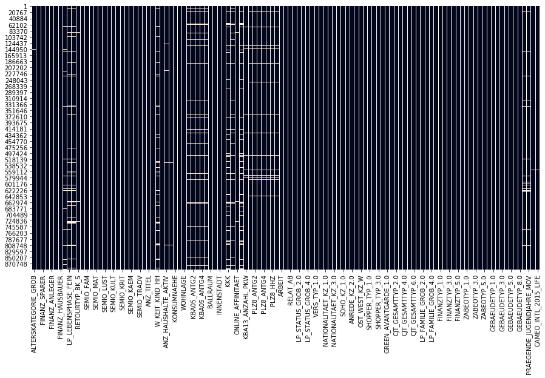

```python
fig, ax = plt.subplots(1,1,figsize=(15,8))
sns.heatmap(azdias_feat_eng.isnull(), cbar=False, ax=ax)
```

Nevertheless, removing all missing values shrinks the dataset by approx. 22% (see result below). If we want to impute missing values, we need to account for different feature types, such as categorical/ordinal and numeric features, respectively.  
Previously, we encoded categorical values as dummy variables, which resulted in missing values being dropped for these categorical variables. As such, we don't have to take care of any categorical features.

```python
1-len(azdias_feat_eng.dropna())/len(azdias_feat_eng)
```

```
0.2158841558546135
```

### Imputation strategy

Importantly and as stated in the section above (1.1.3: Assess Missing Data in Each Row), data seems not to be missing completely at random, but conditional on a subset of feature variables. Consequently, simply removing missing values would result in biased downstream analysis.  
I decided to keep observations that were previously filtered due to specified NaN by row threshold (see (1.1.3: Assess Missing Data in Each Row) and apply the imputation strategy described in the following section.

```python
# recover the dataset
azidas_reset = clean_data(azdias)
```

I will not conduct mean/mode/median imputation, since it will likely result in strong bias, especially if applying unconditional mean imputation across all feature levels for each column (https://academic.oup.com/aje/article/160/1/34/107200, https://stats.stackexchange.com/questions/303722/methods-to-work-around-the-problem-of-missing-data-in-machine-learning). Predictive mean matching will be used because the range of imputed values will encompass the set of observed values only, thus, preserving the original category values for categorical/ordinal features. Moreover, multiple imputation steps will be conducted using the MICE algorithm, which essentially will better capture the uncertainty of imputed values. (https://www.researchgate.net/publication/44203418_MICE_Multivariate_Imputation_by_Chained_Equations_in_R, https://towardsdatascience.com/6-different-ways-to-compensate-for-missing-values-data-imputation-with-examples-6022d9ca0779, https://www.ncbi.nlm.nih.gov/pmc/articles/PMC3074241/). Essentially, 5 imputations steps will be conducted and imputed data will either be combined using mode selection, i.e. imputed value with highest count in the imputed subsets will be selected. A tie/draw (same number of counts in multiple imputation subsets) will be resolved by randomly selecting one value from the 5 imputed subsets.

For each feature to be imputed I will select 20 predictor variables. Using the entire feature set (114 features in azidas_reset) would simply be computationally expensive. Our goal is to capture features with highest predicting power only within the scope of the input dataset, i.e. model generalization and unbiased prediction of new and unseen data is not the objective. As such, we don't need to account for overfitting, from which a model might suffer if using too many predictor variables (curse of dimensionality). Feature selection will be conducted using the random forrest classifier, which inherently ranks features according to how well they are able to discriminate the corresponding classes in the dataset.

### rename dummy-encoded features

For some reason, dummy-encoded categorical features result in the imputation module MICE from statsmodel to throw an error. The cognate error message indicates that this is due to the categorical levels encoded in the transformed features as a float, i.e. LP_STATUS_GROB_1.0, LP_STATUS_GROB_2.0, etc.. As such let's change feature names to encode corresponding level representation as int instead, i.e. LP_STATUS_GROB_1, LP_STATUS_GROB_2.

```python
def rename_mapping(df):
    rename_mapping_summary = defaultdict()
    for col in df.columns:
        col_new = col.split(".")
        if len(col_new) > 1:
            rename_mapping_summary[col] = col_new[0]
    return rename_mapping_summary
```

```python
rename_mapping_dict = rename_mapping(azidas_reset)
```

```python
rename_mapping_dict
```

```
defaultdict(None,
            {'VERS_TYP_1.0': 'VERS_TYP_1',
             'VERS_TYP_2.0': 'VERS_TYP_2',
             'ANREDE_KZ_1.0': 'ANREDE_KZ_1',
             'ANREDE_KZ_2.0': 'ANREDE_KZ_2',
             'GEBAEUDETYP_1.0': 'GEBAEUDETYP_1',
             'GEBAEUDETYP_2.0': 'GEBAEUDETYP_2',
             'GEBAEUDETYP_3.0': 'GEBAEUDETYP_3',
             'GEBAEUDETYP_4.0': 'GEBAEUDETYP_4',
             'GEBAEUDETYP_5.0': 'GEBAEUDETYP_5',
             'GEBAEUDETYP_6.0': 'GEBAEUDETYP_6',
             'GEBAEUDETYP_8.0': 'GEBAEUDETYP_8',
             'GREEN_AVANTGARDE_0.0': 'GREEN_AVANTGARDE_0',
             'GREEN_AVANTGARDE_1.0': 'GREEN_AVANTGARDE_1',
             'LP_FAMILIE_GROB_1.0': 'LP_FAMILIE_GROB_1',
             'LP_FAMILIE_GROB_2.0': 'LP_FAMILIE_GROB_2',
             'LP_FAMILIE_GROB_3.0': 'LP_FAMILIE_GROB_3',
             'LP_FAMILIE_GROB_4.0': 'LP_FAMILIE_GROB_4',
             'LP_FAMILIE_GROB_5.0': 'LP_FAMILIE_GROB_5',
             'SOHO_KZ_0.0': 'SOHO_KZ_0',
             'SOHO_KZ_1.0': 'SOHO_KZ_1',
             'CJT_GESAMTTYP_1.0': 'CJT_GESAMTTYP_1',
             'CJT_GESAMTTYP_2.0': 'CJT_GESAMTTYP_2',
             'CJT_GESAMTTYP_3.0': 'CJT_GESAMTTYP_3',
             'CJT_GESAMTTYP_4.0': 'CJT_GESAMTTYP_4',
             'CJT_GESAMTTYP_5.0': 'CJT_GESAMTTYP_5',
             'CJT_GESAMTTYP_6.0': 'CJT_GESAMTTYP_6',
             'FINANZTYP_1.0': 'FINANZTYP_1',
             'FINANZTYP_2.0': 'FINANZTYP_2',
             'FINANZTYP_3.0': 'FINANZTYP_3',
             'FINANZTYP_4.0': 'FINANZTYP_4',
             'FINANZTYP_5.0': 'FINANZTYP_5',
             'FINANZTYP_6.0': 'FINANZTYP_6',
             'ZABEOTYP_1.0': 'ZABEOTYP_1',
             'ZABEOTYP_2.0': 'ZABEOTYP_2',
             'ZABEOTYP_3.0': 'ZABEOTYP_3',
             'ZABEOTYP_4.0': 'ZABEOTYP_4',
             'ZABEOTYP_5.0': 'ZABEOTYP_5',
             'ZABEOTYP_6.0': 'ZABEOTYP_6',
             'LP_STATUS_GROB_1.0': 'LP_STATUS_GROB_1',
             'LP_STATUS_GROB_2.0': 'LP_STATUS_GROB_2',
             'LP_STATUS_GROB_3.0': 'LP_STATUS_GROB_3',
             'LP_STATUS_GROB_4.0': 'LP_STATUS_GROB_4',
             'LP_STATUS_GROB_5.0': 'LP_STATUS_GROB_5',
             'NATIONALITAET_KZ_1.0': 'NATIONALITAET_KZ_1',
             'NATIONALITAET_KZ_2.0': 'NATIONALITAET_KZ_2',
             'NATIONALITAET_KZ_3.0': 'NATIONALITAET_KZ_3',
             'SHOPPER_TYP_0.0': 'SHOPPER_TYP_0',
             'SHOPPER_TYP_1.0': 'SHOPPER_TYP_1',
             'SHOPPER_TYP_2.0': 'SHOPPER_TYP_2',
             'SHOPPER_TYP_3.0': 'SHOPPER_TYP_3'})
```

```python
azidas_reset.rename(columns=rename_mapping_dict, inplace=True)
```

```python
for k in rename_mapping_dict.values():
    assert k in azidas_reset.columns.values, "feature name not changed"
```

We have no assertion error, which indicates that all names have been changed accordingly. Let's integrate rename functionality into the clean_data function.

### Select all features with missing values

```python
number_nan = azidas_reset.apply(lambda col: pd.isna(col).sum(), 0).values
nan_by_col = list(zip(azidas_reset.columns, number_nan, np.round((number_nan/len(azidas_reset)*100),3)))
nan_by_col = np.array(nan_by_col)
nan_by_col

feature_with_nan = nan_by_col[np.array(list(map(int, nan_by_col[:,1])))>0][:,0]
```

```python
feature_with_nan
```

```
array(['ALTERSKATEGORIE_GROB', 'HEALTH_TYP', 'RETOURTYP_BK_S',
       'ANZ_PERSONEN', 'ANZ_TITEL', 'HH_EINKOMMEN_SCORE',
       'W_KEIT_KIND_HH', 'WOHNDAUER_2008', 'ANZ_HAUSHALTE_AKTIV',
       'ANZ_HH_TITEL', 'KONSUMNAEHE', 'MIN_GEBAEUDEJAHR', 'KBA05_ANTG1',
       'KBA05_ANTG2', 'KBA05_ANTG3', 'KBA05_ANTG4', 'KBA05_GBZ',
       'BALLRAUM', 'EWDICHTE', 'INNENSTADT', 'GEBAEUDETYP_RASTER', 'KKK',
       'MOBI_REGIO', 'ONLINE_AFFINITAET', 'REGIOTYP', 'KBA13_ANZAHL_PKW',
       'PLZ8_ANTG1', 'PLZ8_ANTG2', 'PLZ8_ANTG3', 'PLZ8_ANTG4',
       'PLZ8_BAUMAX', 'PLZ8_HHZ', 'PLZ8_GBZ', 'ARBEIT', 'ORTSGR_KLS9',
       'RELAT_AB', 'PRAEGENDE_JUGENDJAHRE_DECADE',
       'PRAEGENDE_JUGENDJAHRE_MOV', 'CAMEO_INTL_2015_WEALTH',
       'CAMEO_INTL_2015_LIFE', 'WOHNLAGE_TYPE', 'WOHNLAGE_QUALITY'],
      dtype='<U28')
```

### Select feature-set for each feature to be imputed

```python
def feature_selection(y_var, df, number_feat=20):
    """
    fit default random forrest classifier and
    """
    clf = RandomForestClassifier()

    feature_selection_df = df.copy()
    feature_selection_df = feature_selection_df.dropna()
    y = feature_selection_df[y_var]
    X_col = [col for col in feature_selection_df.columns.difference([y_var])]
    X = feature_selection_df[X_col]
    clf.fit(X.values, y.values)

    ranking= sorted([feat_importance for feat_importance\
                     in zip (X_col, clf.feature_importances_)], key=lambda v: v[1], reverse=True)
    return np.array(ranking)[:,0][:number_feat]
```

```python
predictor_var_sets = defaultdict()
for feat in feature_with_nan:
    feature_set = feature_selection(feat, azidas_reset)
    predictor_var_sets[feat] = feature_set
```

[output not shown]

[output cut: 29 more lines]

[output not shown]

```python
predictor_var_sets
```

```
defaultdict(None,
            {'ALTERSKATEGORIE_GROB': array(['SEMIO_PFLICHT', 'SEMIO_ERL', 'SEMIO_TRADV', 'SEMIO_REL',
                    'SEMIO_LUST', 'SEMIO_MAT', 'PRAEGENDE_JUGENDJAHRE_DECADE',
                    'SEMIO_RAT', 'HEALTH_TYP', 'SEMIO_KULT', 'SEMIO_KAEM',
                    'FINANZ_VORSORGER', 'SEMIO_SOZ', 'SEMIO_VERT', 'SEMIO_DOM',
                    'SEMIO_FAM', 'SHOPPER_TYP_0', 'SEMIO_KRIT', 'VERS_TYP_1',
                    'ANREDE_KZ_2'], dtype='<U28'),
             'HEALTH_TYP': array(['ALTERSKATEGORIE_GROB', 'SEMIO_ERL', 'SEMIO_LUST', 'SEMIO_PFLICHT',
                    'SEMIO_KRIT', 'SEMIO_RAT', 'SEMIO_DOM', 'SEMIO_VERT', 'SEMIO_MAT',
                    'SEMIO_FAM', 'SEMIO_SOZ', 'SEMIO_KAEM', 'SEMIO_TRADV', 'SEMIO_REL',
                    'SEMIO_KULT', 'REGIOTYP', 'KKK', 'VERS_TYP_1', 'FINANZ_VORSORGER',
                    'KBA13_ANZAHL_PKW'], dtype='<U28'),
             'RETOURTYP_BK_S': array(['ONLINE_AFFINITAET', 'INNENSTADT', 'FINANZ_VORSORGER',
                    'ORTSGR_KLS9', 'EWDICHTE', 'PRAEGENDE_JUGENDJAHRE_DECADE',
                    'FINANZ_SPARER', 'KBA13_ANZAHL_PKW', 'FINANZ_UNAUFFAELLIGER',
                    'WOHNLAGE_QUALITY', 'ANZ_HAUSHALTE_AKTIV', 'ALTERSKATEGORIE_GROB',
                    'W_KEIT_KIND_HH', 'FINANZ_MINIMALIST', 'SEMIO_PFLICHT', 'BALLRAUM',
                    'SEMIO_REL', 'SEMIO_KAEM', 'MOBI_REGIO', 'KONSUMNAEHE'],
                   dtype='<U28'),
             'ANZ_PERSONEN': array(['LP_FAMILIE_GROB_1', 'LP_FAMILIE_GROB_5', 'LP_FAMILIE_GROB_2',
                    'W_KEIT_KIND_HH', 'ONLINE_AFFINITAET', 'SEMIO_KRIT',
                    'LP_FAMILIE_GROB_4', 'KBA13_ANZAHL_PKW', 'SEMIO_VERT',
                    'HH_EINKOMMEN_SCORE', 'KBA05_ANTG1', 'LP_FAMILIE_GROB_3',
                    'WOHNDAUER_2008', 'ANZ_HAUSHALTE_AKTIV', 'INNENSTADT',
                    'ORTSGR_KLS9', 'REGIOTYP', 'KONSUMNAEHE', 'BALLRAUM', 'MOBI_REGIO'],
                   dtype='<U28'),
             'ANZ_TITEL': array(['ANZ_HH_TITEL', 'LP_STATUS_GROB_3', 'LP_STATUS_GROB_2',
                    'ANZ_HAUSHALTE_AKTIV', 'KBA05_ANTG1', 'LP_STATUS_GROB_5',
                    'KBA13_ANZAHL_PKW', 'ORTSGR_KLS9', 'ONLINE_AFFINITAET',
                    'PRAEGENDE_JUGENDJAHRE_MOV', 'ANZ_PERSONEN', 'GEBAEUDETYP_3',
                    'MOBI_REGIO', 'GEBAEUDETYP_RASTER', 'HH_EINKOMMEN_SCORE',
                    'WOHNLAGE_QUALITY', 'LP_STATUS_GROB_1',
                    'PRAEGENDE_JUGENDJAHRE_DECADE', 'WOHNDAUER_2008', 'REGIOTYP'],
                   dtype='<U28'),
             'HH_EINKOMMEN_SCORE': array(['CAMEO_INTL_2015_LIFE', 'ANZ_HAUSHALTE_AKTIV', 'KBA13_ANZAHL_PKW',
                    'LP_STATUS_GROB_1', 'KBA05_ANTG1', 'CAMEO_INTL_2015_WEALTH',
                    'MOBI_REGIO', 'REGIOTYP', 'ONLINE_AFFINITAET',
                    'GREEN_AVANTGARDE_0', 'ORTSGR_KLS9', 'PLZ8_ANTG3', 'INNENSTADT',
                    'KKK', 'KBA05_ANTG3', 'BALLRAUM', 'FINANZ_MINIMALIST',
                    'KONSUMNAEHE', 'WOHNLAGE_QUALITY', 'W_KEIT_KIND_HH'], dtype='<U28'),
```

[output cut: 200 more lines]

```
                    'REGIOTYP', 'PLZ8_GBZ', 'PLZ8_ANTG1', 'KKK', 'FINANZ_MINIMALIST',
                    'ORTSGR_KLS9', 'KONSUMNAEHE', 'WOHNLAGE_QUALITY',
                    'GREEN_AVANTGARDE_1', 'INNENSTADT'], dtype='<U28'),
             'WOHNLAGE_TYPE': array(['ORTSGR_KLS9', 'WOHNLAGE_QUALITY', 'EWDICHTE', 'INNENSTADT',
                    'ARBEIT', 'SEMIO_DOM', 'RELAT_AB', 'LP_STATUS_GROB_1',
                    'PLZ8_ANTG3', 'KBA05_GBZ', 'PLZ8_ANTG4', 'RETOURTYP_BK_S',
                    'BALLRAUM', 'CAMEO_INTL_2015_LIFE', 'PLZ8_BAUMAX', 'OST_WEST_KZ_W',
                    'GREEN_AVANTGARDE_1', 'KBA05_ANTG4', 'PRAEGENDE_JUGENDJAHRE_MOV',
                    'FINANZ_ANLEGER'], dtype='<U28'),
             'WOHNLAGE_QUALITY': array(['WOHNLAGE_TYPE', 'ORTSGR_KLS9', 'INNENSTADT', 'SEMIO_DOM',
                    'KBA13_ANZAHL_PKW', 'ANZ_HAUSHALTE_AKTIV', 'EWDICHTE', 'REGIOTYP',
                    'BALLRAUM', 'KKK', 'KONSUMNAEHE', 'ONLINE_AFFINITAET',
                    'PLZ8_ANTG1', 'RETOURTYP_BK_S', 'RELAT_AB', 'GEBAEUDETYP_RASTER',
                    'ARBEIT', 'W_KEIT_KIND_HH', 'SEMIO_PFLICHT', 'SEMIO_SOZ'],
                   dtype='<U28')})
```

save identified predictor sets

```python
with open("predictor_var_sets.pkl", "wb") as f_out:
    pickle.dump(predictor_var_sets, f_out)
```

Load predictor_var_sets if necessary

```python
with open("predictor_var_sets.pkl", "rb") as f_in:
    predictor_var_sets = pickle.load(f_in)
```

### Perform imputation

Use a random sample of 200000 cases for each imputation. This is simply to speed up computation

```python
def impute(predictor_var_sets, df, imputation_model=sm.OLS, **options):
    """
    """
    df_copy = df.copy()
    for resp_var in predictor_var_sets.keys():
        if options.get("single_imputation"):
            if resp_var != options.get("single_imputation"):
                continue
        start_time = time.time()
        # select subset
        selected_features = list(predictor_var_sets[resp_var])+[resp_var]
        df_subset = df_copy[selected_features]

        # group indices by missing/not missing
        nan_ind = df.index[df[resp_var].isnull()]
        print(f"Number of missing values: {len(nan_ind)}")
        observed_ind = df.index[df[resp_var].notnull()]
        if options.get("sample"):
            sample_size = options.get("sample")

            # combine all missing samples/rows with a subset of observed
            observed_ind_sample = random.sample(list(observed_ind),sample_size)
            #sample_selection = df_subset.loc[list(nan_ind)+observed_ind_sample]
            df_subset = df_subset.loc[list(nan_ind)+observed_ind_sample]

        print(f"sample size observed: {df_subset[resp_var].notnull().sum()}\n total size: {len(df_subset)}")
        # convert data
        #imp_data = mice.MICEData(sample_selection[selected_features])
        imp_data = mice.MICEData(df_subset[selected_features])
        # define imputation model
        pred_var = " + ".join(predictor_var_sets[resp_var])
        model = resp_var + "~" + pred_var
        print(model)
        # execute imputation
        mice_model = mice.MICE(model, imputation_model, imp_data)

        results = []
        for k in range(5):
            x = mice_model.next_sample()
            imputation_results = imp_data.data.copy()
            imputation_results = imputation_results[resp_var].values
            results.append(imputation_results)
        print(f"proccessing time col {resp_var}: {(time.time()-start_time)/60}min")
        results = np.array(results)
        final_imputation = []
        for idx in range(len(nan_ind)):
            counter = Counter(results[:,idx])
            mode = counter.most_common(1)[0][0]
            final_imputation.append(mode)
        df_copy.loc[nan_ind, resp_var] = final_imputation

    return df_copy
```

```python
azidas_imputation = impute(predictor_var_sets, azidas_reset, sample=200000)
```

[output not shown]

[output cut: 71 more lines]

[output not shown]

```python
for col in predictor_var_sets.keys():
    nan_indices = azidas_reset[azidas_reset[col].isnull()][col].index
    assert azidas_imputation.loc[nan_indices, col].isna().sum() == 0, "imputation incorrect"
```

Save the imputed dataset in order to retrieve it if necessary.

```python
azidas_imputation.to_csv("imputed_dataset_OLS_mice_no_nan_filtering.csv", index=False)
```

Load imputed dataset if necessary

```python
azidas_imputation = pd.read_csv("imputed_dataset_OLS_mice_no_nan_filtering.csv")
```

### Evaluate imputation results

Let's compare the distribution of observed values versus imputed values.

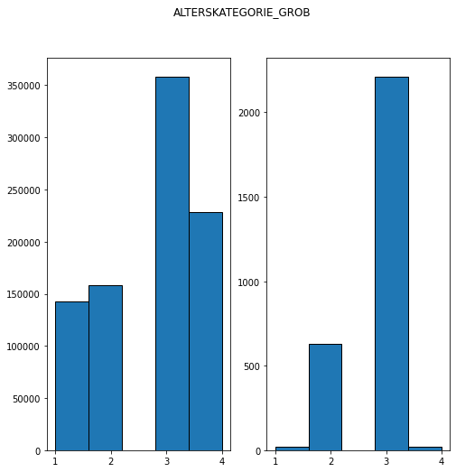

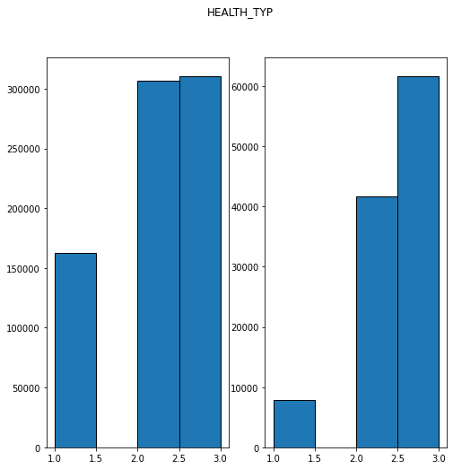

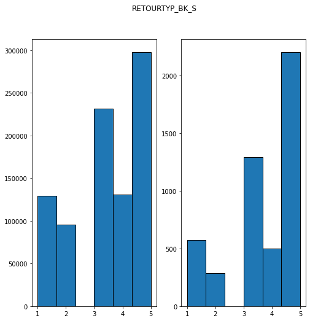

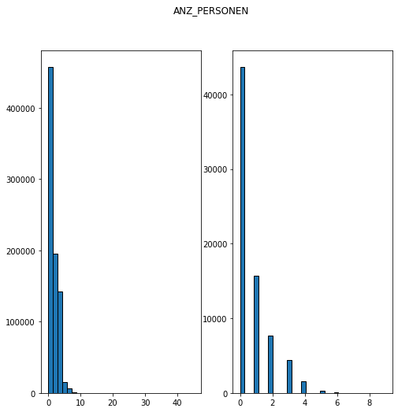

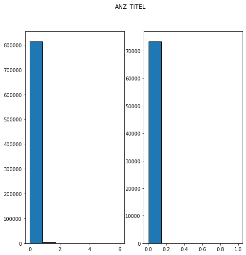

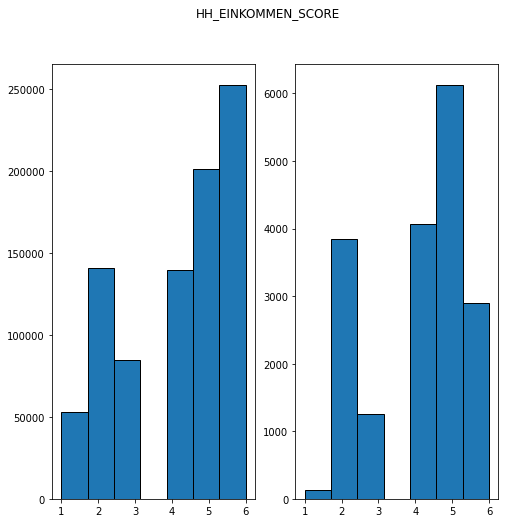

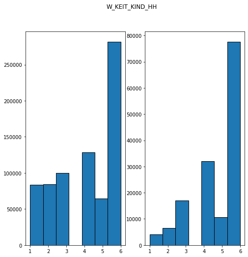

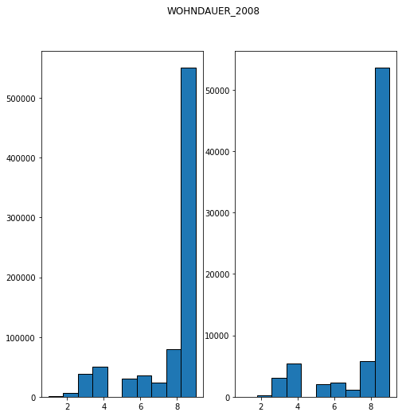

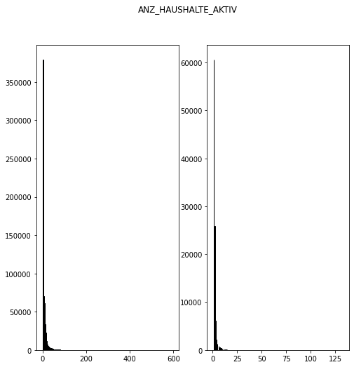

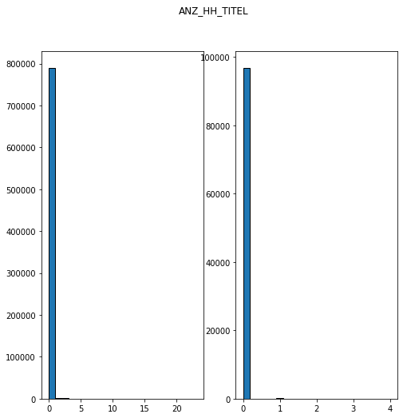

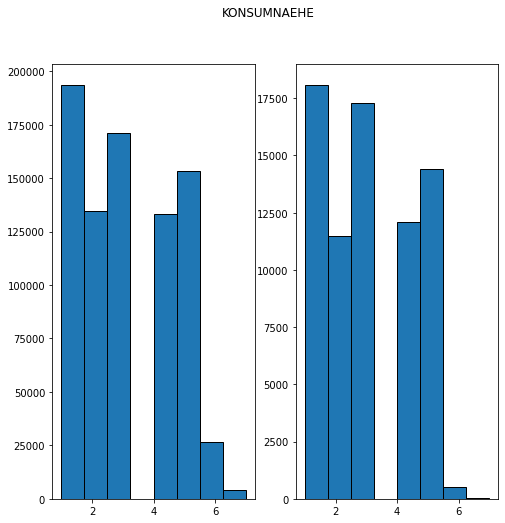

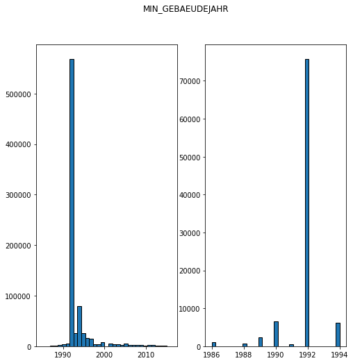

[29 more figures not shown]

```python
for col in predictor_var_sets.keys():
    nan_indices = azidas_reset[azidas_reset[col].isnull()][col].index.values
    bins = len(set(azidas_reset[col].dropna().values))
    fig, ax = plt.subplots(1,2, figsize=(8,8))
    ax[0].hist(azidas_reset[col].dropna(), bins=bins+1, edgecolor="black")
    ax[1].hist(azidas_imputation.loc[nan_indices, col], bins=bins+1, edgecolor="black")
    plt.suptitle(col)
plt.close()
```

Some features show a more similir distribution for observed values vs. imputed valus (PLZ8_ANTG2, PLZ8_BAUMAX or RELAT_AB), as opposed to features with significantly different distributions (CAMEO_INTL_2015_LIFE, CAMEO_INTL_2015_WEALTH, HEALTH_TYP, etc.). In order to better be able to evaluate the quality of imputation, I will sample from observed values for a subset of features (each sample size corresponding to number of missing values in the original dataset) and set the cognate values to NaN. Consequently, I will have a ground-truth dataset for each NaN subset created. Following creating "artificial" NaN subsets, I will apply the same imputation workflow as before with the original dataset.  
Comparing imputed values with the original ground-truth values will eventually provide some insight about the overall imputation quality.

```python
def sample_imputation_set(df, col):
    df_copy = df.copy()

    sample_size=df_copy[col].isnull().sum()
    # remove already present nan from col
    df_copy.dropna(subset=[col], inplace=True)
    # take random index sample with size of original nan subset for cognate col
    sample_idx = random.sample(df_copy[col].index.values.tolist(), sample_size)
    # for sampled indices keep original values
    orig_df = df_copy.loc[sample_idx,:]
    df_copy.loc[sample_idx, col] = np.nan
    # print(df_copy[col].loc[sample_idx[:10]])
    # print(orig_df[col].loc[sample_idx[:10]])
    return sample_idx, df_copy
```

```
Number of missing values: 111196
HEALTH_TYP~ALTERSKATEGORIE_GROB + SEMIO_ERL + SEMIO_LUST + SEMIO_PFLICHT + SEMIO_KRIT + SEMIO_RAT + SEMIO_DOM + SEMIO_VERT + SEMIO_MAT + SEMIO_FAM + SEMIO_SOZ + SEMIO_KAEM + SEMIO_TRADV + SEMIO_REL + SEMIO_KULT + REGIOTYP + KKK + VERS_TYP_1 + FINANZ_VORSORGER + KBA13_ANZAHL_PKW
proccessing time col HEALTH_TYP: 1.4315782984097798min
Number of missing values: 99352
CAMEO_INTL_2015_LIFE~CAMEO_INTL_2015_WEALTH + HH_EINKOMMEN_SCORE + KBA05_ANTG1 + PLZ8_ANTG4 + PLZ8_ANTG2 + MOBI_REGIO + KBA05_GBZ + PLZ8_ANTG3 + KBA13_ANZAHL_PKW + ANZ_HAUSHALTE_AKTIV + REGIOTYP + PLZ8_GBZ + PLZ8_ANTG1 + KKK + FINANZ_MINIMALIST + ORTSGR_KLS9 + KONSUMNAEHE + WOHNLAGE_QUALITY + GREEN_…
proccessing time col CAMEO_INTL_2015_LIFE: 5.200390080610911min
Number of missing values: 99352
CAMEO_INTL_2015_WEALTH~CAMEO_INTL_2015_LIFE + HH_EINKOMMEN_SCORE + KBA05_ANTG1 + PLZ8_ANTG3 + LP_STATUS_GROB_1 + ANZ_HAUSHALTE_AKTIV + PLZ8_ANTG1 + KBA13_ANZAHL_PKW + ORTSGR_KLS9 + ARBEIT + REGIOTYP + MOBI_REGIO + KKK + RELAT_AB + PLZ8_ANTG2 + KONSUMNAEHE + INNENSTADT + BALLRAUM + WOHNLAGE_QUALITY +…
proccessing time col CAMEO_INTL_2015_WEALTH: 5.5190216143925985min
Number of missing values: 116515
PLZ8_ANTG2~PLZ8_BAUMAX + PLZ8_ANTG1 + PLZ8_ANTG3 + KBA13_ANZAHL_PKW + MOBI_REGIO + PLZ8_GBZ + PLZ8_ANTG4 + ORTSGR_KLS9 + ANZ_HAUSHALTE_AKTIV + KONSUMNAEHE + INNENSTADT + EWDICHTE + CAMEO_INTL_2015_WEALTH + WOHNLAGE_QUALITY + PLZ8_HHZ + BALLRAUM + KBA05_ANTG2 + REGIOTYP + RELAT_AB + ONLINE_AFFINITAET
proccessing time col PLZ8_ANTG2: 4.865134414037069min
Number of missing values: 116515
PLZ8_BAUMAX~PLZ8_ANTG2 + PLZ8_ANTG1 + PLZ8_ANTG4 + PLZ8_ANTG3 + EWDICHTE + PLZ8_GBZ + CAMEO_INTL_2015_LIFE + KONSUMNAEHE + MOBI_REGIO + KBA13_ANZAHL_PKW + ORTSGR_KLS9 + GEBAEUDETYP_RASTER + INNENSTADT + BALLRAUM + RELAT_AB + ANZ_HAUSHALTE_AKTIV + KBA05_ANTG1 + GEBAEUDETYP_1 + FINANZ_HAUSBAUER + WOHN…
proccessing time col PLZ8_BAUMAX: 4.504183034102122min
Number of missing values: 97375
RELAT_AB~ARBEIT + ORTSGR_KLS9 + KBA13_ANZAHL_PKW + BALLRAUM + INNENSTADT + EWDICHTE + ANZ_HAUSHALTE_AKTIV + WOHNLAGE_QUALITY + OST_WEST_KZ_W + KONSUMNAEHE + REGIOTYP + OST_WEST_KZ_O + PLZ8_ANTG1 + PLZ8_GBZ + PLZ8_HHZ + PLZ8_ANTG2 + PLZ8_ANTG4 + ONLINE_AFFINITAET + MOBI_REGIO + PLZ8_ANTG3
proccessing time col RELAT_AB: 5.323079299926758min
```

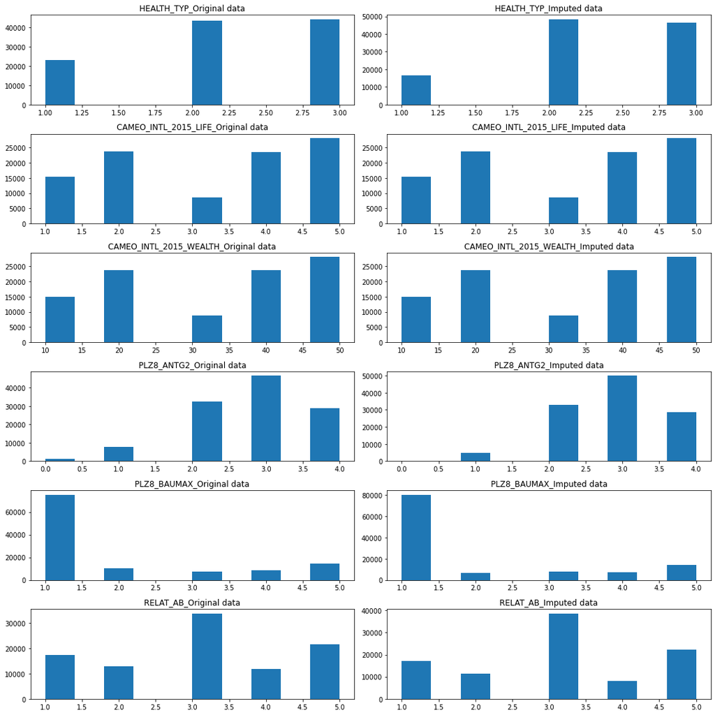

```python
fig, ax = plt.subplots(6,2, figsize=(15,15))
for idx, col in enumerate(["HEALTH_TYP", "CAMEO_INTL_2015_LIFE", "CAMEO_INTL_2015_WEALTH",
            "PLZ8_ANTG2", "PLZ8_BAUMAX", "RELAT_AB"]):
    imputed_idx, imputation_set = sample_imputation_set(azidas_reset, col)
    imputation_set_result = impute(predictor_var_sets, imputation_set, single_imputation=col, sample=200000)
    ax[idx][0].hist(azidas_reset.loc[imputed_idx, col])
    ax[idx][1].hist(imputation_set_result.loc[imputed_idx, col])
    ax[idx][0].set_title(f"{col}_Original data")
    ax[idx][1].set_title(f"{col}_Imputed data")
plt.tight_layout()
plt.show()
```

```python
# Apply feature scaling to the general population demographics data.
scaler = StandardScaler()
azdias_scaled = scaler.fit_transform(azidas_imputation)
azdias_scaled = pd.DataFrame(azdias_scaled, columns=azidas_imputation.columns)
```

```python
azdias_scaled.head()
```

|  | ALTERSKATEGORIE_GROB | FINANZ_MINIMALIST | FINANZ_SPARER | FINANZ_VORSORGER | FINANZ_ANLEGER | FINANZ_UNAUFFAELLIGER | FINANZ_HAUSBAUER | HEALTH_TYP | RETOURTYP_BK_S | SEMIO_SOZ | ... | ANREDE_KZ_1 | ANREDE_KZ_2 | CJT_GESAMTTYP_1 | CJT_GESAMTTYP_2 | CJT_GESAMTTYP_3 | CJT_GESAMTTYP_4 | CJT_GESAMTTYP_5 | CJT_GESAMTTYP_6 | VERS_TYP_1 | VERS_TYP_2 |
| --- | --- | --- | --- | --- | --- | --- | --- | --- | --- | --- | --- | --- | --- | --- | --- | --- | --- | --- | --- | --- | --- |
| 0 | -0.750784 | -0.056416 | 0.804890 | -0.303378 | 1.285741 | 1.429871 | -0.055511 | 1.035627 | 1.113548 | -0.999639 | ... | 1.045218 | -1.045218 | -0.353241 | 2.233739 | -0.461435 | -0.556886 | -0.389460 | -0.456895 | -0.864739 | -0.899772 |
| 1 | -1.742218 | -1.570358 | 1.487601 | -1.059731 | 1.285741 | 0.757254 | 1.422415 | 1.035627 | -1.707798 | 0.541539 | ... | -0.956738 | 0.956738 | -0.353241 | -0.447680 | -0.461435 | -0.556886 | 2.567659 | -0.456895 | -0.864739 | 1.111393 |
| 2 | 0.240651 | -1.570358 | 0.804890 | -1.816084 | -0.675554 | 0.084637 | 1.422415 | 1.035627 | -0.297125 | 0.027813 | ... | -0.956738 | 0.956738 | -0.353241 | -0.447680 | 2.167155 | -0.556886 | -0.389460 | -0.456895 | 1.156419 | -0.899772 |
| 3 | 1.232085 | 0.700556 | -0.560532 | 1.209329 | -0.675554 | -1.260597 | -0.794475 | -0.303849 | -1.002461 | 0.541539 | ... | -0.956738 | 0.956738 | -0.353241 | 2.233739 | -0.461435 | -0.556886 | -0.389460 | -0.456895 | 1.156419 | -0.899772 |
| 4 | 0.240651 | 0.700556 | 0.122179 | 0.452976 | -1.329319 | 0.084637 | -0.794475 | 1.035627 | 1.113548 | 1.055265 | ... | 1.045218 | -1.045218 | -0.353241 | -0.447680 | -0.461435 | -0.556886 | 2.567659 | -0.456895 | -0.864739 | 1.111393 |

5 rows × 114 columns

### Discussion 2.1: Apply Feature Scaling

Before the dataset was standarized (removing mean and scaling to unit variance) missing observations were imputed applying MICE imputation in combination with predictive mean matching. As mentioned earlier, missing observations don't seem to be missing completely at random. As such, simply removing these can result in significantly biasing downstream analysis (for more information see previous section).  
Categorical/ordinal features have implications on the imputation strategy. Simply methods like mean/median/mode imputation are inherently biased. Moreover they are very likely to further increase bias in imputed values, since results need to be converted (rounding) from a float representation to integer numbers that actually represent different classes for each feature. This is also true for the default MICE imputation, since predictions of dependent variables are regression-based. Overall mean/median/mode imputation method would always underestimate underrepresented class variables in case of an imbalanced class distribution. The default MICE method would better account for class imbalance, but nevertheless can corrupt imputation by "class switch", i.e true class variable is 4 but the imputed value is 4.5, which results in final class prediction to be 5.

As a consequence, either classification via supervised machine learning or predictive mean matching in combination with MICE is a good approach to reduce bias in imputation.

### Step 2.2: Perform Dimensionality Reduction

On your scaled data, you are now ready to apply dimensionality reduction techniques.

- Use sklearn's [PCA](http://scikit-learn.org/stable/modules/generated/sklearn.decomposition.PCA.html) class to apply principal component analysis on the data, thus finding the vectors of maximal variance in the data. To start, you should not set any parameters (so all components are computed) or set a number of components that is at least half the number of features (so there's enough features to see the general trend in variability).
- Check out the ratio of variance explained by each principal component as well as the cumulative variance explained. Try plotting the cumulative or sequential values using matplotlib's [`plot()`](https://matplotlib.org/api/_as_gen/matplotlib.pyplot.plot.html) function. Based on what you find, select a value for the number of transformed features you'll retain for the clustering part of the project.
- Once you've made a choice for the number of components to keep, make sure you re-fit a PCA instance to perform the decided-on transformation.

```python
# Apply PCA to the data.
pca = PCA()
azdias_pca = pca.fit_transform(azdias_scaled)
```

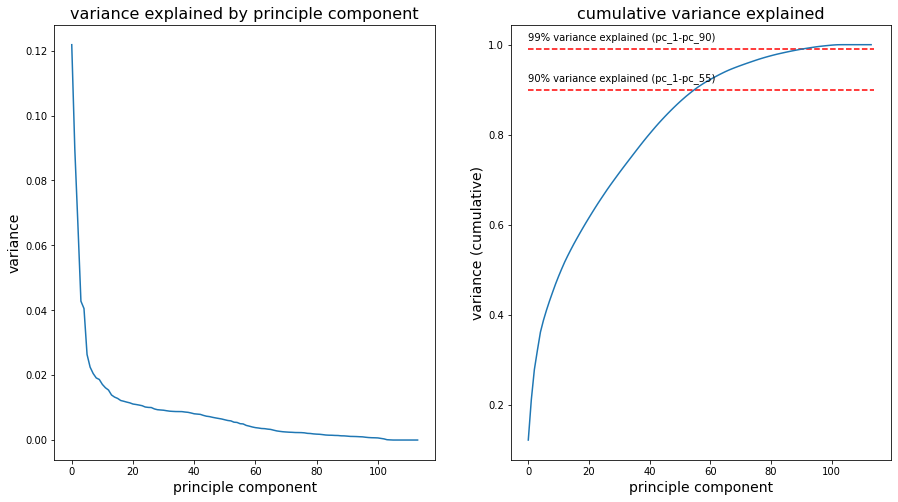

```python
# Investigate the variance accounted for by each principal component.
def plot_variance(pca):

    pca_var = pd.DataFrame(pca.explained_variance_ratio_.reshape(1,114),
                       columns=[f"pc_{idx}" for idx in range(len(pca.explained_variance_ratio_))])
    cumulative_var = pca_var.T.cumsum()
    cumulative_var.rename(columns={0: "cumvar"}, inplace=True)
    cumulative_var["cumvar_before"] = cumulative_var.shift().fillna(0)

    pc_90 = cumulative_var[cumulative_var[0]>=0.9].head(1).index.tolist()[0]
    pc_99 = cumulative_var[cumulative_var[0]>=0.99].head(1).index.tolist()[0]



    fig, ax = plt.subplots(1,2, figsize=(15,8))

    ax[0].plot(pca_var.T[0].values)
    ax[1].plot(cumulative_var[0].values)
    ax[0].set_xlabel("principle component", size=14)
    ax[1].set_xlabel("principle component", size=14)
    ax[0].set_ylabel("variance", size=14)
    ax[1].set_ylabel("variance (cumulative)", size=14)
    ax[0].set_title("variance explained by principle component", size=16)
    ax[1].set_title("cumulative variance explained", size=16)
    ax[1].hlines(0.9, 0, len(pca_var.columns), color="red", linestyle=("--"))
    ax[1].hlines(0.99, 0, len(pca_var.columns), color="red", linestyle=("--"))
    ax[1].text(0, 0.92, f"90% variance explained (pc_1-{pc_90})")
    ax[1].text(0, 1.01, f"99% variance explained (pc_1-{pc_99})")
    plt.show()

plot_variance(pca)
```

```python
# Re-apply PCA to the data while selecting for number of components to retain.
pca = PCA(n_components=55)
azdias_pca = pca.fit_transform(azdias_scaled)
```

### Discussion 2.2: Perform Dimensionality Reduction

After applying principle component analysis we can see that the variance explained by each principle component quickly drops after approx. the first 15 components (see left figure above). So basically, most of the relative variance is captured by only the first 20 components. Nevertheless, it requires the first 55 components to explain at least 90% of the total variance (see right figure above).  
I decided to keep only these 55 principle components, as it requires 35 more components to explain only 9% more variance.

### Step 2.3: Interpret Principal Components

Now that we have our transformed principal components, it's a nice idea to check out the weight of each variable on the first few components to see if they can be interpreted in some fashion.

As a reminder, each principal component is a unit vector that points in the direction of highest variance (after accounting for the variance captured by earlier principal components). The further a weight is from zero, the more the principal component is in the direction of the corresponding feature. If two features have large weights of the same sign (both positive or both negative), then increases in one tend expect to be associated with increases in the other. To contrast, features with different signs can be expected to show a negative correlation: increases in one variable should result in a decrease in the other.

- To investigate the features, you should map each weight to their corresponding feature name, then sort the features according to weight. The most interesting features for each principal component, then, will be those at the beginning and end of the sorted list. Use the data dictionary document to help you understand these most prominent features, their relationships, and what a positive or negative value on the principal component might indicate.
- You should investigate and interpret feature associations from the first three principal components in this substep. To help facilitate this, you should write a function that you can call at any time to print the sorted list of feature weights, for the *i*-th principal component. This might come in handy in the next step of the project, when you interpret the tendencies of the discovered clusters.

```python
# Map weights for the first principal component to corresponding feature names
# and then print the linked values, sorted by weight.
# HINT: Try defining a function here or in a new cell that you can reuse in the
# other cells.
def map_pc_weights(pca, dataset, component):
    weights = pca.components_[component-1]
    mapping = sorted(list(zip(dataset.columns[:len(weights)],
                              pca.components_[component-1])), key=lambda v: v[1], reverse=True)
    for entry in mapping:
        print(entry)

map_pc_weights(pca, azidas_imputation, component=1)
```

```
('PLZ8_ANTG3', 0.19958781788478377)
('PLZ8_ANTG4', 0.1929603710350665)
('LP_STATUS_GROB_1', 0.19046060195755526)
('CAMEO_INTL_2015_LIFE', 0.18530614024179273)
('CAMEO_INTL_2015_WEALTH', 0.1853061402417927)
('PLZ8_BAUMAX', 0.18522644832397817)
('ORTSGR_KLS9', 0.17590460609708247)
('EWDICHTE', 0.1726435142520079)
('HH_EINKOMMEN_SCORE', 0.16334198639325767)
('FINANZ_HAUSBAUER', 0.15136291269056182)
('WOHNLAGE_QUALITY', 0.14948564973090017)
('PLZ8_ANTG2', 0.13748008751246263)
('KBA05_ANTG4', 0.13369182452543743)
('WOHNLAGE_TYPE', 0.1303387550055113)
('ARBEIT', 0.1267629817596834)
('KBA05_ANTG3', 0.11862915936848857)
('RELAT_AB', 0.1182432305492112)
('ANZ_HAUSHALTE_AKTIV', 0.11788362379979309)
('FINANZ_SPARER', 0.1145870551051178)
('FINANZTYP_1', 0.10873512761279061)
('GREEN_AVANTGARDE_0', 0.10443208318359477)
('SEMIO_PFLICHT', 0.08515603859729694)
('SEMIO_REL', 0.07761694689634473)
('PRAEGENDE_JUGENDJAHRE_DECADE', 0.07421415498523416)
('LP_FAMILIE_GROB_1', 0.07310472897634242)
('ZABEOTYP_5', 0.07306305633588295)
('SEMIO_RAT', 0.07123747502764229)
('REGIOTYP', 0.06847460701165986)
('GEBAEUDETYP_3', 0.06752537437413972)
('SEMIO_TRADV', 0.056738776566727635)
('FINANZ_ANLEGER', 0.055262567110888734)
('SEMIO_MAT', 0.05291290564554673)
('FINANZ_UNAUFFAELLIGER', 0.051396920063427234)
('SEMIO_FAM', 0.05035667311582785)
('SEMIO_KAEM', 0.05032932253082066)
('NATIONALITAET_KZ_2', 0.046604140745447095)
('W_KEIT_KIND_HH', 0.045743255787531106)
('OST_WEST_KZ_O', 0.04364275298204733)
('GEBAEUDETYP_8', 0.042397096236195204)
('KKK', 0.04136735392422415)
```

[output cut: 59 more lines]

```
('ZABEOTYP_1', -0.10053322613617927)
('GEBAEUDETYP_RASTER', -0.104330441422588)
('PRAEGENDE_JUGENDJAHRE_MOV', -0.10443208318359476)
('GREEN_AVANTGARDE_1', -0.10443208318359476)
('BALLRAUM', -0.10808850071881795)
('LP_STATUS_GROB_5', -0.11087145770367286)
('LP_STATUS_GROB_4', -0.11491924299664669)
('INNENSTADT', -0.142591137186916)
('PLZ8_GBZ', -0.14519292548139737)
('KONSUMNAEHE', -0.1475845376917199)
('KBA05_GBZ', -0.19089471798739702)
('FINANZ_MINIMALIST', -0.19257429560366587)
('KBA05_ANTG1', -0.1966489673049465)
('PLZ8_ANTG1', -0.19787395697500648)
('MOBI_REGIO', -0.21188494576380743)
```

```python
# Map weights for the second principal component to corresponding feature names
# and then print the linked values, sorted by weight.

map_pc_weights(pca, azidas_imputation, component=2)
```

```
('ALTERSKATEGORIE_GROB', 0.24093493790244783)
('FINANZ_VORSORGER', 0.23199120289329964)
('SEMIO_ERL', 0.19328490706435075)
('RETOURTYP_BK_S', 0.15870295589410086)
('SEMIO_LUST', 0.15842213320047122)
('ZABEOTYP_3', 0.15567766985625972)
('CJT_GESAMTTYP_2', 0.11357586130015766)
('W_KEIT_KIND_HH', 0.1094546630794214)
('FINANZTYP_5', 0.10894568911423017)
('FINANZTYP_2', 0.10423334111606807)
('NATIONALITAET_KZ_1', 0.10251966515564233)
('FINANZ_MINIMALIST', 0.09477167756147428)
('FINANZ_HAUSBAUER', 0.08761188077664803)
('SHOPPER_TYP_3', 0.08586769798473264)
('FINANZTYP_6', 0.08416395385176015)
('CJT_GESAMTTYP_1', 0.07644933534041927)
('SOHO_KZ_0', 0.07543636470648754)
('PLZ8_ANTG3', 0.07095804872428554)
('PLZ8_ANTG4', 0.0705532618438028)
('PLZ8_BAUMAX', 0.07017313639975052)
('ORTSGR_KLS9', 0.06332027174893218)
('EWDICHTE', 0.06310385751571722)
('HH_EINKOMMEN_SCORE', 0.06299626973635603)
('CAMEO_INTL_2015_WEALTH', 0.060467531874713085)
('CAMEO_INTL_2015_LIFE', 0.060467531874713085)
('LP_FAMILIE_GROB_1', 0.05796125745387096)
('ANZ_HAUSHALTE_AKTIV', 0.056908922807795866)
('WOHNDAUER_2008', 0.05559554957219364)
('KBA05_ANTG4', 0.05513111715817149)
('VERS_TYP_2', 0.05131632092898648)
('ARBEIT', 0.048687660368041064)
('PLZ8_ANTG2', 0.04725658155773186)
('RELAT_AB', 0.0469257058864212)
('WOHNLAGE_TYPE', 0.04645184666370535)
('WOHNLAGE_QUALITY', 0.04367909997154514)
('LP_FAMILIE_GROB_2', 0.038295910657670476)
('KBA05_ANTG3', 0.037076671264440995)
('GEBAEUDETYP_3', 0.034133270178000635)
('OST_WEST_KZ_O', 0.03351836058369837)
('ANREDE_KZ_2', 0.03166951074183719)
```

[output cut: 59 more lines]

```
('ZABEOTYP_5', -0.08966626516956855)
('FINANZTYP_4', -0.119861973486405)
('FINANZTYP_1', -0.12018455856028652)
('ONLINE_AFFINITAET', -0.1464738992961851)
('SEMIO_MAT', -0.14658777428822295)
('SEMIO_KULT', -0.14781118751073946)
('SEMIO_FAM', -0.14972253228114493)
('SEMIO_RAT', -0.17803024883573518)
('SEMIO_TRADV', -0.2024864789079827)
('SEMIO_PFLICHT', -0.21958368463288505)
('FINANZ_ANLEGER', -0.22126603824119304)
('SEMIO_REL', -0.2301600666300561)
('FINANZ_UNAUFFAELLIGER', -0.23219308322817486)
('FINANZ_SPARER', -0.24387734708894057)
('PRAEGENDE_JUGENDJAHRE_DECADE', -0.2549283781905949)
```

```python
# Map weights for the third principal component to corresponding feature names
# and then print the linked values, sorted by weight.

map_pc_weights(pca, azidas_imputation, component=3)
```

```
('SEMIO_VERT', 0.31383577531779877)
('ANREDE_KZ_1', 0.3031110710884305)
('SEMIO_KULT', 0.2659201863883509)
('SEMIO_SOZ', 0.26464707189939957)
('SEMIO_FAM', 0.19672712773897602)
('SOHO_KZ_0', 0.1371641155573898)
('SHOPPER_TYP_0', 0.12986364796137906)
('ZABEOTYP_1', 0.11791664810635366)
('FINANZTYP_5', 0.10909850088637914)
('FINANZ_MINIMALIST', 0.08752856959438289)
('NATIONALITAET_KZ_1', 0.08575626530821608)
('SHOPPER_TYP_1', 0.07975170177300644)
('PRAEGENDE_JUGENDJAHRE_MOV', 0.07536839852396311)
('GREEN_AVANTGARDE_1', 0.07536839852396311)
('SEMIO_MAT', 0.06906231899521292)
('OST_WEST_KZ_W', 0.06796056618783787)
('SEMIO_REL', 0.05516627462730021)
('ZABEOTYP_6', 0.053727641652579296)
('VERS_TYP_2', 0.052435393602464526)
('PLZ8_BAUMAX', 0.052355670276952135)
('ANZ_PERSONEN', 0.05058568236283197)
('PLZ8_ANTG4', 0.04383174354872409)
('NATIONALITAET_KZ_2', 0.04329705817935548)
('RETOURTYP_BK_S', 0.04293850679242356)
('LP_STATUS_GROB_5', 0.042908697421935114)
('CJT_GESAMTTYP_4', 0.04217758074453899)
('GEBAEUDETYP_3', 0.042108371257585445)
('HH_EINKOMMEN_SCORE', 0.04035772425343468)
('VERS_TYP_1', 0.039315494318551095)
('PLZ8_ANTG3', 0.038328220277156905)
('ANZ_HAUSHALTE_AKTIV', 0.03595476455704619)
('SEMIO_TRADV', 0.03467363446897535)
('ORTSGR_KLS9', 0.034512792475551564)
('EWDICHTE', 0.03237651739394129)
('FINANZTYP_3', 0.03236370712798556)
('CJT_GESAMTTYP_3', 0.030806860345007837)
('GEBAEUDETYP_1', 0.02832922377437069)
('CAMEO_INTL_2015_WEALTH', 0.02678267626042907)
('CAMEO_INTL_2015_LIFE', 0.026782676260429066)
('FINANZTYP_6', 0.026369797767344272)
```

[output cut: 59 more lines]

```
('SHOPPER_TYP_2', -0.04863137924377961)
('FINANZ_HAUSBAUER', -0.05322050018169279)
('FINANZ_UNAUFFAELLIGER', -0.07234967619276957)
('LP_STATUS_GROB_2', -0.07278476701776368)
('GREEN_AVANTGARDE_0', -0.0753683985239631)
('CJT_GESAMTTYP_6', -0.08276131053688024)
('FINANZTYP_4', -0.09829177085864584)
('SEMIO_RAT', -0.11319811998214083)
('ZABEOTYP_3', -0.11650646747768598)
('FINANZ_ANLEGER', -0.14111656548665727)
('SEMIO_ERL', -0.16637442165868538)
('SEMIO_DOM', -0.2775626867035833)
('SEMIO_KRIT', -0.2816681124227969)
('ANREDE_KZ_2', -0.3031110710884305)
('SEMIO_KAEM', -0.3105019121329355)
```

pos PLZ8_ANTG3 and PLZ8_ANTG4 neg PLZ8_ANTG1 and MOBI_REGIO

### Discussion 2.3: Interpret Principal Components

#### First principle component

The 2 features (PLZ8_ANTG3 and PLZ8_ANTG4) correlating with highest pos weight describe the amount of residential buildings with 6-10 and >10 housing units (basically medium-/big appartment buildings) in designated geographical area, respectively. In contrast, the 2 lowest neg weight are associated with features (PLZ8_ANTG1 and MOBI_REGIO) that describe the the amount of residential buildings with 1-2 housing units in designated geographical area, which corresponds to small appartment buildings or family homes. MOBI_REGION describes movement patters for cognate geographical area. Amount of housing units per residential building is likely correlating with area of living on a macroscopic scale. We might expect bigger residential buildings (more housing units) to be rather closer to the city/ city center, which simply has a higher population density, thus, requiring more housing units per area. In contrast, smaller residential buildings/family homes can be expected to be rather located in rural areas and more distant from the city-/city center, respectively. Also, I would expect the amount of type of residential buildings to be a proxy for household economic factors, which again, I suggest to be reciprocally correlated with respect to the type of residential building, i.e. higher income in areas with high percentage of residential buildings with 1-2 housing units/family homes. As such, it makes sense that these features are negatively correlated. Reciprocal correlation between MOBI_REGIO (indicating amount of movement in designated area) and PLZ8_ANTG3/PLZ8_ANTG4 is in accordance with literature, which suggests higher movement rates for low-income households and young families (https://www.huduser.gov/portal/periodicals/cityscpe/vol14num3/Cityscape_Nov2012_res_mobility_neigh.pdf). Again, assuming both higher-income and higher age residents in regions with a lower number of high-number housing units buildings on average.

#### Second principle component

For the second principle component the weights with highest and lowest values, respectively, map to features ALTERSKATEGORIE_GROB (pos weights) and PRAEGENDE_JUGENDJAHRE_DECADE. ALTERSKATEGORIE_GROB and PRAEGENDE_JUGENDJAHRE_DECADE simpy represent the age of individuals at different resolutions. In general it is to be expected that these features capture a lot of variance (thus, highest weights) if we assume that the dataset is representative of the general population. The reciprocal correlation is simply due to reversed order of cognate class value encodings, i.e. 1 represents young individuals and old individuals in ALTERSKATEGORIE_GROB and PRAEGENDE_JUGENDJAHRE_DECADE, respectively (correspondingly higher numbers vice versa). Also highest absolute weights are associated with features FINANZ_VORSORGER (pos weight) and FINANZ_SPARER/FINANZ_UNAUFFAELLIGER/FINANZ_ANLEGER (neg weights). These features belong to the same category but each describing a different financial type. The level mapping/translation is as follows:

Dimension translations:

- MINIMALIST: low financial interest
- SPARER: money-saver
- VORSORGER: be prepared
- ANLEGER: investor
- UNAUFFAELLIGER: inconspicuous
- HAUSBAUER: home ownership

It is a bit difficult to really discriminate these financial types on a qualitative level. I would expect qualitatively different types to be negatively correlated, e.g. individuals with no interest in saving/investing money vs. those labeled as investors. We see that type "investor" positively correlates with type "money-saver", however both reciprocally corelating with type "be prepared" (financial provisioning). My understanding of type "be prepared" is very similar to "investor". Both invest money with the objective of higher returns in the future. As such, I would have expected to rather see FINANZ_MINIMALIST reciprocally correlating with FINANZ_VORSORGER/FINANZ_SPARER. However FINANZ_MINIMALIST only ranks 12 within the positive weight set.

#### Third principle component

For the third principle component, we can observe highest abs weights being associated with the personality typology feature class (SEMIO), which is subdivided in multiple levels (SEMIO_VERT, SEMIO_KULT, etc.). SEMIO_VERT, SEMIO_KULT, SEMIO_SOZ and SEMIO_FAM have positive weights. SEMIO_KAEM, SEMIO_KRIT, SEMIO_DOM, SEMIO_ERL have negative weights. The results (reciprocal relationship between 2 subsets within the same set) suggest that the personality typology can be divided in at least 2 higher level groups. Let's have a look at the personality typology encodings.

The subset with positive weights consists of following personality types:

- dreamful
- cultural-minded
- socially-minded
- family-minded

The subset with negative weights consists of following personality types:

- combative attitude
- critical-minded
- dominant-minded
- event-oriented

Without trying to conduct any psychological analysis, it seems that the first subset represents individuals with a higher awareness of what is going on around them, being more prone to engage with their social environment. So I would label those individuals as being more liberal and emphatic. In contrast, the adjectives describing the second subset have a strong notion of being egoistic, self-absorbed and rather focused on single individuals instead of the cognate social environment. In analogy to previous classification, I would label those individuals being part of the second subset as being more conservative and authotity focused.

## Step 3: Clustering

### Step 3.1: Apply Clustering to General Population

You've assessed and cleaned the demographics data, then scaled and transformed them. Now, it's time to see how the data clusters in the principal components space. In this substep, you will apply k-means clustering to the dataset and use the average within-cluster distances from each point to their assigned cluster's centroid to decide on a number of clusters to keep.

- Use sklearn's KMeans class to perform k-means clustering on the PCA-transformed data.
- Then, compute the average difference from each point to its assigned cluster's center. **Hint**: The KMeans object's `.score()` method might be useful here, but note that in sklearn, scores tend to be defined so that larger is better. Try applying it to a small, toy dataset, or use an internet search to help your understanding.
- Perform the above two steps for a number of different cluster counts. You can then see how the average distance decreases with an increasing number of clusters. However, each additional cluster provides a smaller net benefit. Use this fact to select a final number of clusters in which to group the data. **Warning**: because of the large size of the dataset, it can take a long time for the algorithm to resolve. The more clusters to fit, the longer the algorithm will take. You should test for cluster counts through at least 10 clusters to get the full picture, but you shouldn't need to test for a number of clusters above about 30.
- Once you've selected a final number of clusters to use, re-fit a KMeans instance to perform the clustering operation. Make sure that you also obtain the cluster assignments for the general demographics data, since you'll be using them in the final Step 3.3.

```python
# Over a number of different cluster counts...
scores = []
sse = []
with tqdm(total=30) as p_bar:
    for c in range(1,31):
        p_bar.update(1)
        kmeans = KMeans(n_clusters=c)
        kmeans.fit(azdias_pca)
        score = kmeans.score(azdias_pca)
        scores.append(score)
        sse.append(kmeans.inertia_)

    # run k-means clustering on the data and...


    # compute the average within-cluster distances.
```

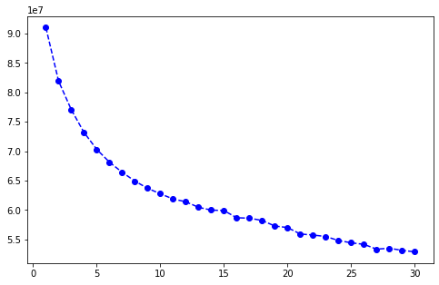

```python
# Investigate the change in within-cluster distance across number of clusters.
# HINT: Use matplotlib's plot function to visualize this relationship.
fig, ax = plt.subplots(1,1, figsize=(8,5))
ax.plot([idx+1 for idx in range(len(scores))], list(map(abs,scores)), 'bo--')
plt.show()
```

```python
# Re-fit the k-means model with the selected number of clusters and obtain
# cluster predictions for the general population demographics data.
kmeans = KMeans(n_clusters=12)
cluster = kmeans.fit_predict(azdias_pca)
```

### Distribution of cluster counts (number of observations by cluster)

### Discussion 3.1: Apply Clustering to General Population

It seems that the dicrease in average sum of all distances for data samples and their corresponding cluster center starts to follow a linear trend after approximatly 10-12 clusters (marking the "elbow"). As such I choose a final KMeans model with 12 clusters.

### Step 3.2: Apply All Steps to the Customer Data

Now that you have clusters and cluster centers for the general population, it's time to see how the customer data maps on to those clusters. Take care to not confuse this for re-fitting all of the models to the customer data. Instead, you're going to use the fits from the general population to clean, transform, and cluster the customer data. In the last step of the project, you will interpret how the general population fits apply to the customer data.

- Don't forget when loading in the customers data, that it is semicolon (`;`) delimited.
- Apply the same feature wrangling, selection, and engineering steps to the customer demographics using the `clean_data()` function you created earlier. (You can assume that the customer demographics data has similar meaning behind missing data patterns as the general demographics data.)
- Use the sklearn objects from the general demographics data, and apply their transformations to the customers data. That is, you should not be using a `.fit()` or `.fit_transform()` method to re-fit the old objects, nor should you be creating new sklearn objects! Carry the data through the feature scaling, PCA, and clustering steps, obtaining cluster assignments for all of the data in the customer demographics data.

```python
# Load in the customer demographics data.
customers_raw = pd.read_csv("Udacity_CUSTOMERS_Subset.csv", delimiter=";")
```

```python
# Apply preprocessing, feature transformation, and clustering from the general
# demographics onto the customer data, obtaining cluster predictions for the
# customer demographics data.
customers = clean_data(customers_raw)
rename_mapping_dict = rename_mapping(customers)
customers.rename(columns=rename_mapping_dict, inplace=True)
```

```python
rename_mapping_dict
```

```
defaultdict(None,
            {'VERS_TYP_1.0': 'VERS_TYP_1',
             'VERS_TYP_2.0': 'VERS_TYP_2',
             'ANREDE_KZ_1.0': 'ANREDE_KZ_1',
             'ANREDE_KZ_2.0': 'ANREDE_KZ_2',
             'GEBAEUDETYP_1.0': 'GEBAEUDETYP_1',
             'GEBAEUDETYP_2.0': 'GEBAEUDETYP_2',
             'GEBAEUDETYP_3.0': 'GEBAEUDETYP_3',
             'GEBAEUDETYP_4.0': 'GEBAEUDETYP_4',
             'GEBAEUDETYP_6.0': 'GEBAEUDETYP_6',
             'GEBAEUDETYP_8.0': 'GEBAEUDETYP_8',
             'GREEN_AVANTGARDE_0.0': 'GREEN_AVANTGARDE_0',
             'GREEN_AVANTGARDE_1.0': 'GREEN_AVANTGARDE_1',
             'LP_FAMILIE_GROB_1.0': 'LP_FAMILIE_GROB_1',
             'LP_FAMILIE_GROB_2.0': 'LP_FAMILIE_GROB_2',
             'LP_FAMILIE_GROB_3.0': 'LP_FAMILIE_GROB_3',
             'LP_FAMILIE_GROB_4.0': 'LP_FAMILIE_GROB_4',
             'LP_FAMILIE_GROB_5.0': 'LP_FAMILIE_GROB_5',
             'SOHO_KZ_0.0': 'SOHO_KZ_0',
             'SOHO_KZ_1.0': 'SOHO_KZ_1',
             'CJT_GESAMTTYP_1.0': 'CJT_GESAMTTYP_1',
             'CJT_GESAMTTYP_2.0': 'CJT_GESAMTTYP_2',
             'CJT_GESAMTTYP_3.0': 'CJT_GESAMTTYP_3',
             'CJT_GESAMTTYP_4.0': 'CJT_GESAMTTYP_4',
             'CJT_GESAMTTYP_5.0': 'CJT_GESAMTTYP_5',
             'CJT_GESAMTTYP_6.0': 'CJT_GESAMTTYP_6',
             'FINANZTYP_1.0': 'FINANZTYP_1',
             'FINANZTYP_2.0': 'FINANZTYP_2',
             'FINANZTYP_3.0': 'FINANZTYP_3',
             'FINANZTYP_4.0': 'FINANZTYP_4',
             'FINANZTYP_5.0': 'FINANZTYP_5',
             'FINANZTYP_6.0': 'FINANZTYP_6',
             'ZABEOTYP_1.0': 'ZABEOTYP_1',
             'ZABEOTYP_2.0': 'ZABEOTYP_2',
             'ZABEOTYP_3.0': 'ZABEOTYP_3',
             'ZABEOTYP_4.0': 'ZABEOTYP_4',
             'ZABEOTYP_5.0': 'ZABEOTYP_5',
             'ZABEOTYP_6.0': 'ZABEOTYP_6',
             'LP_STATUS_GROB_1.0': 'LP_STATUS_GROB_1',
             'LP_STATUS_GROB_2.0': 'LP_STATUS_GROB_2',
             'LP_STATUS_GROB_3.0': 'LP_STATUS_GROB_3',
             'LP_STATUS_GROB_4.0': 'LP_STATUS_GROB_4',
             'LP_STATUS_GROB_5.0': 'LP_STATUS_GROB_5',
             'NATIONALITAET_KZ_1.0': 'NATIONALITAET_KZ_1',
             'NATIONALITAET_KZ_2.0': 'NATIONALITAET_KZ_2',
             'NATIONALITAET_KZ_3.0': 'NATIONALITAET_KZ_3',
             'SHOPPER_TYP_0.0': 'SHOPPER_TYP_0',
             'SHOPPER_TYP_1.0': 'SHOPPER_TYP_1',
             'SHOPPER_TYP_2.0': 'SHOPPER_TYP_2',
             'SHOPPER_TYP_3.0': 'SHOPPER_TYP_3'})
```

### Imputation

load the predictor variable set and impute missing values according to previously described strategy. Use all observed values for each feature to be imputed (dataset is significantly smaller).

```python
with open("predictor_var_sets.pkl", "rb") as f_in:
    predictor_var_sets = pickle.load(f_in)
```

```python
customers_imputation = impute(predictor_var_sets, customers)
```

```
Number of missing values: 240
sample size observed: 191412
 total size: 191652
ALTERSKATEGORIE_GROB~SEMIO_PFLICHT + SEMIO_ERL + SEMIO_TRADV + SEMIO_REL + SEMIO_LUST + SEMIO_MAT + PRAEGENDE_JUGENDJAHRE_DECADE + SEMIO_RAT + HEALTH_TYP + SEMIO_KULT + SEMIO_KAEM + FINANZ_VORSORGER + SEMIO_SOZ + SEMIO_VERT + SEMIO_DOM + SEMIO_FAM + SHOPPER_TYP_0 + SEMIO_KRIT + VERS_TYP_1 + ANREDE_K…
proccessing time col ALTERSKATEGORIE_GROB: 0.7024003863334656min
Number of missing values: 48990
sample size observed: 142662
 total size: 191652
HEALTH_TYP~ALTERSKATEGORIE_GROB + SEMIO_ERL + SEMIO_LUST + SEMIO_PFLICHT + SEMIO_KRIT + SEMIO_RAT + SEMIO_DOM + SEMIO_VERT + SEMIO_MAT + SEMIO_FAM + SEMIO_SOZ + SEMIO_KAEM + SEMIO_TRADV + SEMIO_REL + SEMIO_KULT + REGIOTYP + KKK + VERS_TYP_1 + FINANZ_VORSORGER + KBA13_ANZAHL_PKW
proccessing time col HEALTH_TYP: 0.9577521363894145min
Number of missing values: 3213
sample size observed: 188439
 total size: 191652
RETOURTYP_BK_S~ONLINE_AFFINITAET + INNENSTADT + FINANZ_VORSORGER + ORTSGR_KLS9 + EWDICHTE + PRAEGENDE_JUGENDJAHRE_DECADE + FINANZ_SPARER + KBA13_ANZAHL_PKW + FINANZ_UNAUFFAELLIGER + WOHNLAGE_QUALITY + ANZ_HAUSHALTE_AKTIV + ALTERSKATEGORIE_GROB + W_KEIT_KIND_HH + FINANZ_MINIMALIST + SEMIO_PFLICHT + B…
proccessing time col RETOURTYP_BK_S: 3.039116601149241min
Number of missing values: 46596
sample size observed: 145056
 total size: 191652
ANZ_PERSONEN~LP_FAMILIE_GROB_1 + LP_FAMILIE_GROB_5 + LP_FAMILIE_GROB_2 + W_KEIT_KIND_HH + ONLINE_AFFINITAET + SEMIO_KRIT + LP_FAMILIE_GROB_4 + KBA13_ANZAHL_PKW + SEMIO_VERT + HH_EINKOMMEN_SCORE + KBA05_ANTG1 + LP_FAMILIE_GROB_3 + WOHNDAUER_2008 + ANZ_HAUSHALTE_AKTIV + INNENSTADT + ORTSGR_KLS9 + REGI…
proccessing time col ANZ_PERSONEN: 3.1317145307858785min
Number of missing values: 46596
sample size observed: 145056
 total size: 191652
ANZ_TITEL~ANZ_HH_TITEL + LP_STATUS_GROB_3 + LP_STATUS_GROB_2 + ANZ_HAUSHALTE_AKTIV + KBA05_ANTG1 + LP_STATUS_GROB_5 + KBA13_ANZAHL_PKW + ORTSGR_KLS9 + ONLINE_AFFINITAET + PRAEGENDE_JUGENDJAHRE_MOV + ANZ_PERSONEN + GEBAEUDETYP_3 + MOBI_REGIO + GEBAEUDETYP_RASTER + HH_EINKOMMEN_SCORE + WOHNLAGE_QUALIT…
proccessing time col ANZ_TITEL: 3.4069833874702455min
Number of missing values: 2968
sample size observed: 188684
 total size: 191652
HH_EINKOMMEN_SCORE~CAMEO_INTL_2015_LIFE + ANZ_HAUSHALTE_AKTIV + KBA13_ANZAHL_PKW + LP_STATUS_GROB_1 + KBA05_ANTG1 + CAMEO_INTL_2015_WEALTH + MOBI_REGIO + REGIOTYP + ONLINE_AFFINITAET + GREEN_AVANTGARDE_0 + ORTSGR_KLS9 + PLZ8_ANTG3 + INNENSTADT + KKK + KBA05_ANTG3 + BALLRAUM + FINANZ_MINIMALIST + KON…
proccessing time col HH_EINKOMMEN_SCORE: 4.120916001001993min
Number of missing values: 56937
sample size observed: 134715
 total size: 191652
W_KEIT_KIND_HH~REGIOTYP + ANZ_PERSONEN + PRAEGENDE_JUGENDJAHRE_DECADE + LP_FAMILIE_GROB_1 + SEMIO_LUST + FINANZ_SPARER + FINANZ_HAUSBAUER + FINANZ_VORSORGER + LP_FAMILIE_GROB_4 + LP_FAMILIE_GROB_5 + ONLINE_AFFINITAET + KBA13_ANZAHL_PKW + LP_FAMILIE_GROB_3 + FINANZ_ANLEGER + LP_FAMILIE_GROB_2 + SEMIO…
proccessing time col W_KEIT_KIND_HH: 1.5044404824574789min
Number of missing values: 46596
sample size observed: 145056
 total size: 191652
WOHNDAUER_2008~KBA13_ANZAHL_PKW + ONLINE_AFFINITAET + ANZ_HAUSHALTE_AKTIV + INNENSTADT + ORTSGR_KLS9 + KONSUMNAEHE + BALLRAUM + PRAEGENDE_JUGENDJAHRE_DECADE + REGIOTYP + WOHNLAGE_QUALITY + RELAT_AB + GEBAEUDETYP_RASTER + SEMIO_LUST + EWDICHTE + PLZ8_HHZ + ANZ_PERSONEN + PLZ8_GBZ + FINANZ_SPARER + AR…
proccessing time col WOHNDAUER_2008: 3.9049959540367127min
```

[output cut: 155 more lines]

```
Number of missing values: 50554
sample size observed: 141098
 total size: 191652
CAMEO_INTL_2015_LIFE~CAMEO_INTL_2015_WEALTH + HH_EINKOMMEN_SCORE + KBA05_ANTG1 + PLZ8_ANTG4 + PLZ8_ANTG2 + MOBI_REGIO + KBA05_GBZ + PLZ8_ANTG3 + KBA13_ANZAHL_PKW + ANZ_HAUSHALTE_AKTIV + REGIOTYP + PLZ8_GBZ + PLZ8_ANTG1 + KKK + FINANZ_MINIMALIST + ORTSGR_KLS9 + KONSUMNAEHE + WOHNLAGE_QUALITY + GREEN_…
proccessing time col CAMEO_INTL_2015_LIFE: 0.47006046772003174min
Number of missing values: 49927
sample size observed: 141725
 total size: 191652
WOHNLAGE_TYPE~ORTSGR_KLS9 + WOHNLAGE_QUALITY + EWDICHTE + INNENSTADT + ARBEIT + SEMIO_DOM + RELAT_AB + LP_STATUS_GROB_1 + PLZ8_ANTG3 + KBA05_GBZ + PLZ8_ANTG4 + RETOURTYP_BK_S + BALLRAUM + CAMEO_INTL_2015_LIFE + PLZ8_BAUMAX + OST_WEST_KZ_W + GREEN_AVANTGARDE_1 + KBA05_ANTG4 + PRAEGENDE_JUGENDJAHRE_MO…
proccessing time col WOHNLAGE_TYPE: 0.46434006690979min
Number of missing values: 49927
sample size observed: 141725
 total size: 191652
WOHNLAGE_QUALITY~WOHNLAGE_TYPE + ORTSGR_KLS9 + INNENSTADT + SEMIO_DOM + KBA13_ANZAHL_PKW + ANZ_HAUSHALTE_AKTIV + EWDICHTE + REGIOTYP + BALLRAUM + KKK + KONSUMNAEHE + ONLINE_AFFINITAET + PLZ8_ANTG1 + RETOURTYP_BK_S + RELAT_AB + GEBAEUDETYP_RASTER + ARBEIT + W_KEIT_KIND_HH + SEMIO_PFLICHT + SEMIO_SOZ
proccessing time col WOHNLAGE_QUALITY: 0.2599934975306193min
```

Save the imputed customer dataset

```python
customers_imputation.to_csv("customer_dataset_cleaned_imputed.csv", index=False)
```

```python
customers_imputation = pd.read_csv("customer_dataset_cleaned_imputed.csv")
```

```python
customers_imputation.head()
```

|  | ALTERSKATEGORIE_GROB | FINANZ_MINIMALIST | FINANZ_SPARER | FINANZ_VORSORGER | FINANZ_ANLEGER | FINANZ_UNAUFFAELLIGER | FINANZ_HAUSBAUER | HEALTH_TYP | RETOURTYP_BK_S | SEMIO_SOZ | ... | LP_STATUS_GROB_3 | LP_STATUS_GROB_4 | LP_STATUS_GROB_5 | NATIONALITAET_KZ_1 | NATIONALITAET_KZ_2 | NATIONALITAET_KZ_3 | SHOPPER_TYP_0 | SHOPPER_TYP_1 | SHOPPER_TYP_2 | SHOPPER_TYP_3 |
| --- | --- | --- | --- | --- | --- | --- | --- | --- | --- | --- | --- | --- | --- | --- | --- | --- | --- | --- | --- | --- | --- |
| 0 | 4.0 | 5.0 | 1.0 | 5.0 | 1.0 | 2.0 | 2.0 | 1.0 | 5.0 | 6.0 | ... | 0 | 0 | 1 | 1 | 0 | 0 | 0 | 0 | 0 | 1 |
| 1 | 4.0 | 5.0 | 1.0 | 5.0 | 1.0 | 3.0 | 2.0 | 1.0 | 5.0 | 3.0 | ... | 0 | 0 | 0 | 1 | 0 | 0 | 0 | 0 | 0 | 1 |
| 2 | 4.0 | 5.0 | 1.0 | 5.0 | 1.0 | 4.0 | 4.0 | 2.0 | 5.0 | 2.0 | ... | 0 | 0 | 1 | 1 | 0 | 0 | 0 | 1 | 0 | 0 |
| 3 | 4.0 | 5.0 | 1.0 | 5.0 | 2.0 | 1.0 | 2.0 | 2.0 | 3.0 | 6.0 | ... | 0 | 1 | 0 | 1 | 0 | 0 | 1 | 0 | 0 | 0 |
| 4 | 3.0 | 3.0 | 1.0 | 4.0 | 4.0 | 5.0 | 2.0 | 3.0 | 5.0 | 4.0 | ... | 0 | 0 | 0 | 1 | 0 | 0 | 0 | 1 | 0 | 0 |

5 rows × 113 columns

```python
len(azdias_scaled.columns)
```

```
114
```

```python
len(azidas_imputation.columns)
```

```
115
```

```python
set(azidas_imputation.columns).difference(set(azdias_scaled.columns))
```

```
{'cluster'}
```

### Scaling

Scaling the customer dataset using previously fitted StandarScaler object returns an error, which indicates a mismatch between the number of columns in the Demographics data for the general population of Germany versus the customer dataset, i.e. different number of features after preprocessing both datasets (114 vs. 113 columns).

```python
set(azidas_imputation.columns).difference(set(customers_imputation.columns))
```

```
{'GEBAEUDETYP_5'}
```

In fact, we can see that the general population dataset contains the feature GEBAEUDETYP_5, which is missing from the other dataset. This finding suggests that for the feature GEBAEUDETYP no observation corresponding to value 5 is present in the dataset. Consequently, GEBAEUDETYP_5 feature will not result from dummy-encoding, which is part of the preprocessing step.  
Let's confirm this finding by analysing the set of values for the feature GEBAUDETYP.

```python
set(customers_raw["GEBAEUDETYP"].dropna().values.tolist())
```

```
{1.0, 2.0, 3.0, 4.0, 6.0, 8.0}
```

Indeed, the feature GEBAUDETYP encodes no such value. In order to be compatible with initialized and fitted sklearn objects, we simply need to add a GEBAEUDETYP_5 column to the imputed (no missing values, because of dummy-encoding!!) customer dataset (dummy-encoded as all 0).

```python
customers_imputation["GEBAEUDETYP_5"] = 0
```

```python
columns = customers_imputation.columns
customers_scaled = scaler.transform(customers_imputation)
customers_scaled = pd.DataFrame(customers_scaled, columns=columns)
```

```python
customers_scaled.head()
```

|  | ALTERSKATEGORIE_GROB | FINANZ_MINIMALIST | FINANZ_SPARER | FINANZ_VORSORGER | FINANZ_ANLEGER | FINANZ_UNAUFFAELLIGER | FINANZ_HAUSBAUER | HEALTH_TYP | RETOURTYP_BK_S | SEMIO_SOZ | ... | LP_STATUS_GROB_4 | LP_STATUS_GROB_5 | NATIONALITAET_KZ_1 | NATIONALITAET_KZ_2 | NATIONALITAET_KZ_3 | SHOPPER_TYP_0 | SHOPPER_TYP_1 | SHOPPER_TYP_2 | SHOPPER_TYP_3 | GEBAEUDETYP_5 |
| --- | --- | --- | --- | --- | --- | --- | --- | --- | --- | --- | --- | --- | --- | --- | --- | --- | --- | --- | --- | --- | --- |
| 0 | 1.232085 | 1.457527 | -1.243244 | 1.209329 | -1.329319 | -0.587980 | -0.794475 | -1.643325 | 1.113548 | 1.055265 | ... | -0.956738 | 0.956738 | 2.830929 | -0.44768 | -0.461435 | -0.556886 | -0.389460 | -0.456895 | 1.156419 | -0.899772 |
| 1 | 1.232085 | 1.457527 | -1.243244 | 1.209329 | -1.329319 | 0.084637 | -0.794475 | -1.643325 | 1.113548 | -0.485913 | ... | -0.956738 | -1.045218 | 2.830929 | -0.44768 | -0.461435 | -0.556886 | -0.389460 | -0.456895 | 1.156419 | -0.899772 |
| 2 | 1.232085 | 1.457527 | -1.243244 | 1.209329 | -1.329319 | 0.757254 | 0.683452 | -0.303849 | 1.113548 | -0.999639 | ... | -0.956738 | 0.956738 | 2.830929 | -0.44768 | -0.461435 | -0.556886 | 2.567659 | -0.456895 | -0.864739 | -0.899772 |
| 3 | 1.232085 | 1.457527 | -1.243244 | 1.209329 | -0.675554 | -1.260597 | -0.794475 | -0.303849 | -0.297125 | 1.055265 | ... | 1.045218 | -1.045218 | 2.830929 | -0.44768 | -0.461435 | 1.795700 | -0.389460 | -0.456895 | -0.864739 | -0.899772 |
| 4 | 0.240651 | -0.056416 | -1.243244 | 0.452976 | 0.631976 | 1.429871 | -0.794475 | 1.035627 | 1.113548 | 0.027813 | ... | -0.956738 | -1.045218 | 2.830929 | -0.44768 | -0.461435 | -0.556886 | 2.567659 | -0.456895 | -0.864739 | -0.899772 |

5 rows × 114 columns

### Dimensionality reduction

```python
customers_pca = pca.transform(customers_scaled)
```

### Clustering

```python
customers_cluster = kmeans.predict(customers_pca)
```

### Step 3.3: Compare Customer Data to Demographics Data

At this point, you have clustered data based on demographics of the general population of Germany, and seen how the customer data for a mail-order sales company maps onto those demographic clusters. In this final substep, you will compare the two cluster distributions to see where the strongest customer base for the company is.

Consider the proportion of persons in each cluster for the general population, and the proportions for the customers. If we think the company's customer base to be universal, then the cluster assignment proportions should be fairly similar between the two. If there are only particular segments of the population that are interested in the company's products, then we should see a mismatch from one to the other. If there is a higher proportion of persons in a cluster for the customer data compared to the general population (e.g. 5% of persons are assigned to a cluster for the general population, but 15% of the customer data is closest to that cluster's centroid) then that suggests the people in that cluster to be a target audience for the company. On the other hand, the proportion of the data in a cluster being larger in the general population than the customer data (e.g. only 2% of customers closest to a population centroid that captures 6% of the data) suggests that group of persons to be outside of the target demographics.

Take a look at the following points in this step:

- Compute the proportion of data points in each cluster for the general population and the customer data. Visualizations will be useful here: both for the individual dataset proportions, but also to visualize the ratios in cluster representation between groups. Seaborn's [`countplot()`](https://seaborn.pydata.org/generated/seaborn.countplot.html) or [`barplot()`](https://seaborn.pydata.org/generated/seaborn.barplot.html) function could be handy.
  - Recall the analysis you performed in step 1.1.3 of the project, where you separated out certain data points from the dataset if they had more than a specified threshold of missing values. If you found that this group was qualitatively different from the main bulk of the data, you should treat this as an additional data cluster in this analysis. Make sure that you account for the number of data points in this subset, for both the general population and customer datasets, when making your computations!
- Which cluster or clusters are overrepresented in the customer dataset compared to the general population? Select at least one such cluster and infer what kind of people might be represented by that cluster. Use the principal component interpretations from step 2.3 or look at additional components to help you make this inference. Alternatively, you can use the `.inverse_transform()` method of the PCA and StandardScaler objects to transform centroids back to the original data space and interpret the retrieved values directly.
- Perform a similar investigation for the underrepresented clusters. Which cluster or clusters are underrepresented in the customer dataset compared to the general population, and what kinds of people are typified by these clusters?

```python
# Compare the proportion of data in each cluster for the customer data to the
# proportion of data in each cluster for the general population.

def plot_cluster_distribution(cluster_set, dataset, x_label, ax=None, **options):
    if not ax:
        fig, ax = plt.subplots(1,1, figsize=(10,5))
    counts = np.bincount(cluster_set)
    rel_idx = np.where(counts>0)[0]
    counts = counts[rel_idx]
    ax2 = ax.twinx()

    ax.bar(range(len(counts)), (counts/(sum(counts)))*100, align='center')
    ax2.plot(range(len(counts)), counts,marker='o', c='navy', linewidth=4)

    ax.set(xticks=range(len(counts)), xlim=[-1, len(counts)])
    ax.set_xticklabels(rel_idx)

    ax.set_ylabel("Percentage of population by cluster", size=14)
    ax2.set_ylabel("Counts by cluster", size=14)
    ax.set_xlabel(f"{x_label}", size=14)
    if options.get("feature"):
        ax.set_title(f"{options.get('feature')}")

    plt.suptitle(f"Distribution of cluster size ({dataset})", size=16)
```

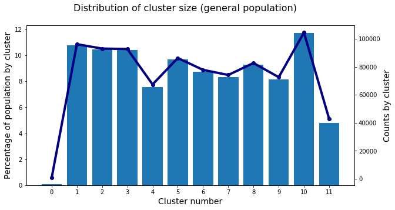

```python
plot_cluster_distribution(cluster, dataset="general population", x_label="Cluster number")
```

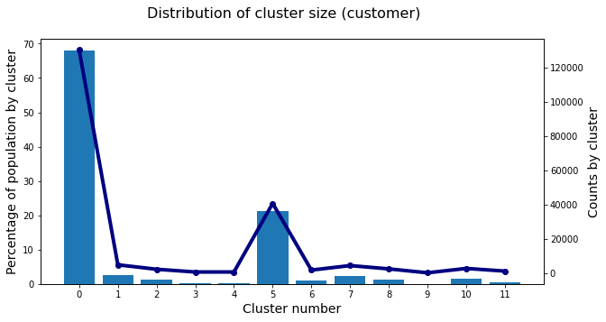

```python
plot_cluster_distribution(customers_cluster, dataset="customer", x_label="Cluster number")
```

We can see that cluster 0 is highly underrepresented in the general population (< 1% of total sample size). Interestingly, cluster 0 is by far the major cluster within the customer population (> 60% of total sample size). Similarly, cluster 5 is overrepresented in the customer dataset in comparison to the general population dataset (> 20% of total sample size versus < 10% of total sample size).  
This suggestes that the major customer target groups are associated with cluster 0 and 5, respectively.

```python
azidas_imputation_copy = azidas_imputation.copy()
customers_imputation_copy = customers_imputation.copy()

azidas_imputation_copy["cluster"] = cluster
customers_imputation_copy["cluster"] = customers_cluster
```

### Results overrepresented cluster

#### features associated with residential area and living habits

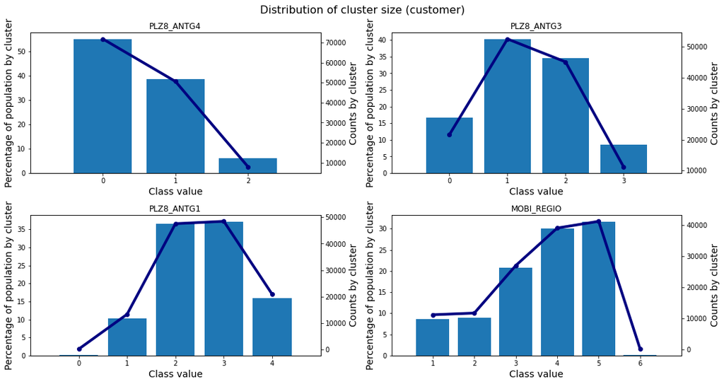

```python
# What kinds of people are part of a cluster that is overrepresented in the
# customer data compared to the general population?
feature_1_cluster_0 = customers_imputation_copy.loc[customers_imputation_copy["cluster"]==0, "PLZ8_ANTG4"]
feature_2_cluster_0 = customers_imputation_copy.loc[customers_imputation_copy["cluster"]==0, "PLZ8_ANTG3"]
feature_3_cluster_0 = customers_imputation_copy.loc[customers_imputation_copy["cluster"]==0, "PLZ8_ANTG1"]
feature_4_cluster_0 = customers_imputation_copy.loc[customers_imputation_copy["cluster"]==0, "MOBI_REGIO"]
fig, ax = plt.subplots(2,2, figsize=(15,8))

plot_cluster_distribution(feature_1_cluster_0, "customer", ax=ax[0,0], feature="PLZ8_ANTG4", x_label="Class value")
plot_cluster_distribution(feature_2_cluster_0, "customer", ax=ax[0,1], feature="PLZ8_ANTG3", x_label="Class value")
plot_cluster_distribution(feature_3_cluster_0, "customer", ax=ax[1,0], feature="PLZ8_ANTG1", x_label="Class value")
plot_cluster_distribution(feature_4_cluster_0, "customer", ax=ax[1,1], feature="MOBI_REGIO", x_label="Class value")
plt.tight_layout()
```

The features shown in the figure above were identified as being associated with highest absolute weights in the first principle components vector (Discussion 2.3: Interpret Principal Components).

#### features associated with age

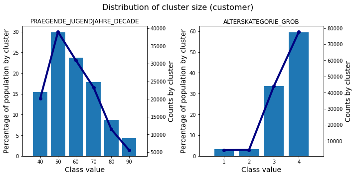

```python
feature_5_cluster_0 = customers_imputation_copy.loc[customers_imputation_copy["cluster"]==0, "PRAEGENDE_JUGENDJAHRE_DECADE"]
feature_6_cluster_0 = customers_imputation_copy.loc[customers_imputation_copy["cluster"]==0, "ALTERSKATEGORIE_GROB"]
fig, ax = plt.subplots(1,2, figsize=(10,5))

plot_cluster_distribution(feature_5_cluster_0, "customer", ax=ax[0], feature="PRAEGENDE_JUGENDJAHRE_DECADE", x_label="Class value")
plot_cluster_distribution(feature_6_cluster_0, "customer", ax=ax[1], feature="ALTERSKATEGORIE_GROB", x_label="Class value")
plt.tight_layout()
```

#### features associated with personality traits

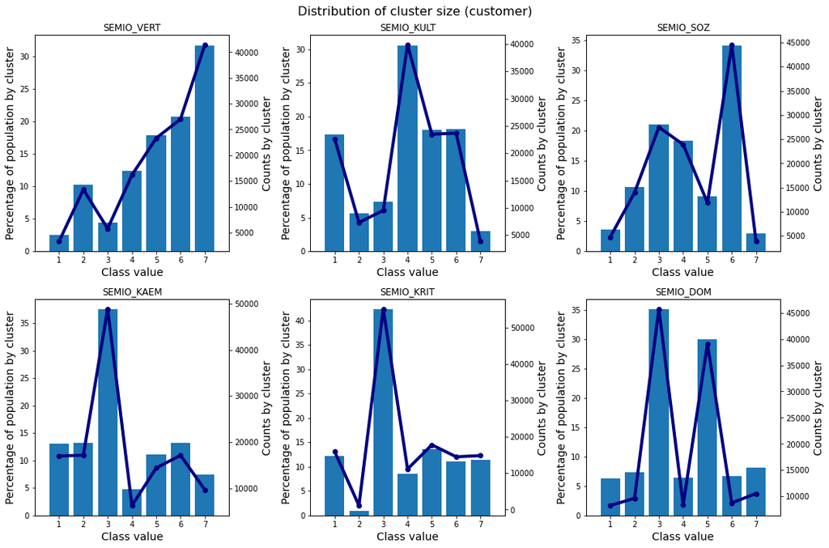

```python
feature_7_cluster_0 = customers_imputation_copy.loc[customers_imputation_copy["cluster"]==0, "SEMIO_VERT"]
feature_8_cluster_0 = customers_imputation_copy.loc[customers_imputation_copy["cluster"]==0, "SEMIO_KULT"]
feature_9_cluster_0 = customers_imputation_copy.loc[customers_imputation_copy["cluster"]==0, "SEMIO_SOZ"]

feature_10_cluster_0 = customers_imputation_copy.loc[customers_imputation_copy["cluster"]==0, "SEMIO_KAEM"]
feature_11_cluster_0 = customers_imputation_copy.loc[customers_imputation_copy["cluster"]==0, "SEMIO_KRIT"]
feature_12_cluster_0 = customers_imputation_copy.loc[customers_imputation_copy["cluster"]==0, "SEMIO_DOM"]

fig, ax = plt.subplots(2,3, figsize=(15,10))

plot_cluster_distribution(feature_7_cluster_0, "customer", ax=ax[0,0], feature="SEMIO_VERT", x_label="Class value")
plot_cluster_distribution(feature_8_cluster_0, "customer", ax=ax[0,1], feature="SEMIO_KULT", x_label="Class value")
plot_cluster_distribution(feature_9_cluster_0, "customer", ax=ax[0,2], feature="SEMIO_SOZ", x_label="Class value")
plot_cluster_distribution(feature_10_cluster_0, "customer", ax=ax[1,0], feature="SEMIO_KAEM", x_label="Class value")
plot_cluster_distribution(feature_11_cluster_0, "customer", ax=ax[1,1], feature="SEMIO_KRIT", x_label="Class value")
plot_cluster_distribution(feature_12_cluster_0, "customer", ax=ax[1,2], feature="SEMIO_DOM", x_label="Class value")
plt.tight_layout()
```

For the features representing combatitive-attitude (SEMIO_KAEM), critical-minded (SEMIO_KRIT) and dominant-minded (SEMIO_DOM) character traits, respectively, the most frequent class value is associated with high-affinity (class variable 3) towards the corresponding character trait. In general, the distribution of combatitive-attitude and critical-minded feature is more skewed towards high affiliation subset (class variables 1,2, 3; approx. 64% for combatitive-attitude and approx. 56% for critical-minded). In contrast, the distribution of low and high-affinity subsets, respectively, is more equally distributed for the dominant-minded character trait.

### Results underrepresented cluster

#### features associated with residential area and living habits

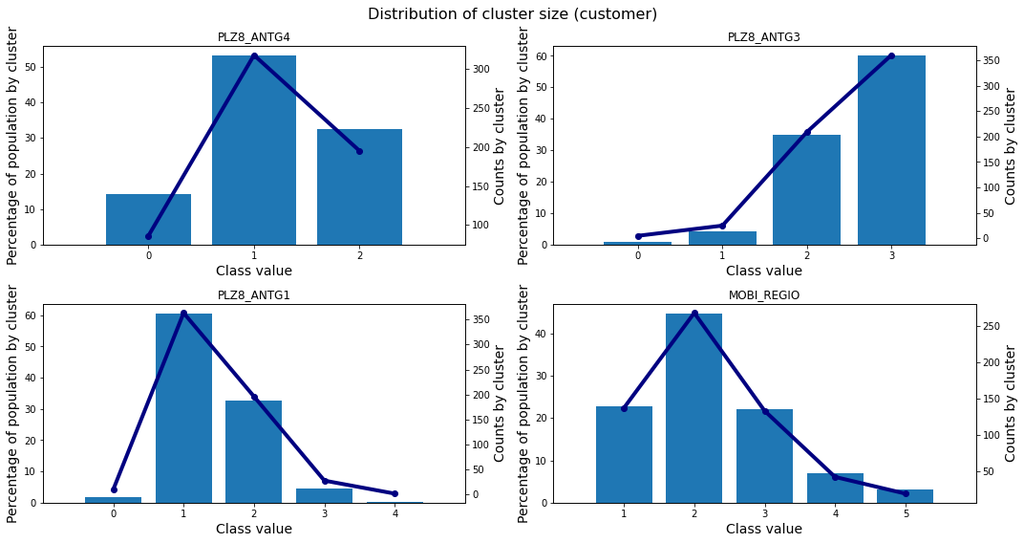

```python
# What kinds of people are part of a cluster that is underrepresented in the
# customer data compared to the general population?
feature_1_cluster_3 = customers_imputation_copy.loc[customers_imputation_copy["cluster"]==3, "PLZ8_ANTG4"]
feature_2_cluster_3 = customers_imputation_copy.loc[customers_imputation_copy["cluster"]==3, "PLZ8_ANTG3"]
feature_3_cluster_3 = customers_imputation_copy.loc[customers_imputation_copy["cluster"]==3, "PLZ8_ANTG1"]
feature_4_cluster_3 = customers_imputation_copy.loc[customers_imputation_copy["cluster"]==3, "MOBI_REGIO"]
fig, ax = plt.subplots(2,2, figsize=(15,8))

plot_cluster_distribution(feature_1_cluster_3, "customer", ax=ax[0,0], feature="PLZ8_ANTG4", x_label="Class value")
plot_cluster_distribution(feature_2_cluster_3, "customer", ax=ax[0,1], feature="PLZ8_ANTG3", x_label="Class value")
plot_cluster_distribution(feature_3_cluster_3, "customer", ax=ax[1,0], feature="PLZ8_ANTG1", x_label="Class value")
plot_cluster_distribution(feature_4_cluster_3, "customer", ax=ax[1,1], feature="MOBI_REGIO", x_label="Class value")
plt.tight_layout()
```